# Proyecto Final — Econometría Financiera

Modelos econométricos para la gestión de un portafolio de 10 acciones de EE.UU.

Natali Maya Landa

09 de November de 2026

**Maestría en Finanzas (MEF) — EGADE Business School, Tecnológico de Monterrey** **Materia:** Econometría Financiera (FZ4038)

# 1 Introducción

## 1.1 Objetivo del proyecto

Aplicar modelos econométricos (regresión lineal simple y múltiple, datos panel, series de tiempo ARIMA y modelos de volatilidad GARCH) a un portafolio de 10 acciones de EE.UU. para entender su riesgo, evaluar si su comportamiento es predecible y sustentar con evidencia la estrategia del portafolio en el simulador HowMarketsWorks.

## 1.2 Acciones del portafolio

| Ticker | Empresa | Sector |
| --- | --- | --- |
| NVDA | NVIDIA | Tecnología / semiconductores |
| MSFT | Microsoft | Tecnología / software |
| AAPL | Apple | Tecnología / hardware |
| AVGO | Broadcom | Tecnología / semiconductores |
| AMD | Advanced Micro Devices | Tecnología / semiconductores |
| JPM | JPMorgan Chase | Financiero / banca |
| WMT | Walmart | Consumo defensivo |
| XOM | Exxon Mobil | Energía |
| V | Visa | Financiero / pagos |
| JNJ | Johnson & Johnson | Salud / farmacéutica |

Nueve acciones provienen de las actividades de clase; JNJ se incorporó para diversificar hacia el sector salud con una acción de bajo riesgo de mercado.

## 1.3 Datos y periodo

| Modelo | Frecuencia | Periodo | Fuente |
| --- | --- | --- | --- |
| Regresión simple y múltiple | Diaria | 3-ene-2023 a 6-nov-2026 | Yahoo Finance (`quantmod`) |
| Datos panel | Trimestral | 2023Q1 a 2026Q3 | Yahoo Finance (`quantmod`) |
| Series de tiempo (forecast) | 1 hora y 5 minutos | dic-2023 / ago-2026 a 6-nov-2026 | Yahoo Finance (servicio de gráficas) |
| GARCH y estrategia | Diaria | 3-ene-2023 a 6-nov-2026 | Yahoo Finance (`quantmod`) |

**Nota sobre la fuente de datos:** se utilizó Yahoo Finance porque permite descargar todos los datos directamente desde R, lo que hace el análisis completamente reproducible. Los precios diarios están ajustados por splits y dividendos. Para que los resultados sean reproducibles, los datos se descargaron una sola vez y se guardaron en los archivos `precios_diarios_guardados.rds`, `intradia_1h.rds` e `intradia_5m.rds`, que se incluyen en el repositorio.

## 1.4 Estructura del documento

Cada parte presenta los resultados para las 10 acciones en tablas resumen y profundiza en tres casos representativos: **NVDA** (alto riesgo de mercado), **JNJ** (bajo riesgo de mercado) y **WMT** (acción defensiva). Las interpretaciones indican la hipótesis nula de cada prueba, el nivel de significancia y su implicación para la toma de decisiones.

# 2 Parte 1. Regresión lineal simple y múltiple

## 2.1 Objetivo

Analizar 10 acciones del portafolio en HowMarketsWorks con modelos econométricos para entender su riesgo frente al mercado y sustentar la estrategia del portafolio. Esta primera parte cubre la descarga de datos, el modelo de mercado (regresión simple) y una regresión múltiple con variables macro-financieras.

## 2.2 Paquetes

```r
paquetes <- c("quantmod", "lmtest", "car", "sandwich", "knitr")
faltan <- paquetes[!paquetes %in% installed.packages()[, "Package"]]
if (length(faltan) > 0) install.packages(faltan)

library(quantmod)   # descarga de Yahoo Finance
library(lmtest)     # pruebas sobre residuales (Breusch-Pagan, Durbin-Watson)
library(car)        # VIF y pruebas de hipótesis lineales
library(sandwich)   # errores estándar robustos
library(knitr)      # tablas
```

## 2.3 Datos

### 2.3.1 Instrumentos y periodo

| Tipo | Instrumentos |
| --- | --- |
| Acciones | NVDA, MSFT, AAPL, AVGO, AMD, JPM, WMT, XOM, V, JNJ |
| Mercado | S&P 500 (^GSPC) |
| Variables macro-financieras | VIX (^VIX), rendimiento del Treasury a 10 años (^TNX), índice dólar (DX-Y.NYB) |

El periodo se fija del 1 de enero de 2023 al 6 de noviembre de 2026 para que los resultados no cambien cada vez que se ejecute el documento.

```r
acciones <- c("NVDA", "MSFT", "AAPL", "AVGO", "AMD",
              "JPM", "WMT", "XOM", "V", "JNJ")
inicio <- "2023-01-01"
fin    <- "2026-11-07"   # Yahoo excluye la fecha final: incluye hasta el 6-nov-2026

bajar <- function(simbolo) {
  bajar_guardado(simbolo, inicio, fin)
}

# Precios ajustados (splits y dividendos) de las 10 acciones
precios <- NULL
for (s in acciones) {
  p <- Ad(bajar(s))
  colnames(p) <- s
  precios <- if (is.null(precios)) p else merge(precios, p)
}

# Variables de mercado
mercado <- merge(Ad(bajar("^GSPC")), Cl(bajar("^VIX")),
                 Cl(bajar("^TNX")),  Cl(bajar("DX-Y.NYB")))
colnames(mercado) <- c("SPX", "VIX", "TNX", "DXY")

# Se usan solo los días en que opera la bolsa de EE.UU. (calendario de las acciones).
# VIX y DXY tienen días distintos; los huecos se llenan con el último dato disponible.
datos <- merge(precios, mercado, join = "left")
datos <- na.locf(datos)

dim(datos)
```

```
## [1] 966  14
```

```r
head(datos, 3)
```

```
##                NVDA     MSFT     AAPL     AVGO   AMD      JPM      WMT      XOM
## 2023-01-03 14.26730 232.5106 122.8767 52.62887 64.02 123.1210 45.85538 94.18097
## 2023-01-04 14.69985 222.3398 124.1441 53.27166 64.66 124.2690 45.90646 94.45509
## 2023-01-05 14.21746 215.7501 122.8276 52.77530 62.33 124.2415 45.75000 96.56845
##                   V      JNJ     SPX   VIX   TNX    DXY
## 2023-01-03 201.5449 160.0811 3824.14 22.90 3.793 104.52
## 2023-01-04 206.6178 161.8239 3852.97 22.01 3.709 104.25
## 2023-01-05 205.1600 160.6291 3808.10 22.46 3.720 105.04
```

```r
tail(datos, 3)
```

```
##              NVDA   MSFT   AAPL   AVGO    AMD    JPM    WMT    XOM      V
## 2026-11-04 200.13 555.80 349.51 325.48 488.78 352.11 129.17 169.27 436.57
## 2026-11-05 181.60 535.93 344.17 291.53 404.40 337.34 127.72 165.30 422.59
## 2026-11-06 186.64 530.61 342.37 293.69 449.04 334.49 125.52 165.87 422.65
##               JNJ     SPX   VIX   TNX    DXY
## 2026-11-04 276.32 7688.62 16.61 4.894 101.51
## 2026-11-05 272.32 7353.73 28.18 4.837 101.55
## 2026-11-06 276.22 7376.86 25.64 4.859 102.30
```

### 2.3.2 Rendimientos y variables explicativas

- **Acciones y S&P 500:** rendimiento logarítmico diario, $r_t = \ln(P_t / P_{t-1})$.
- **VIX:** cambio diario en puntos.
- **TNX:** cambio diario de la tasa a 10 años, en puntos porcentuales.
- **DXY:** rendimiento logarítmico diario del dólar.

```r
rend <- diff(log(datos[, c(acciones, "SPX")]))

dVIX <- diff(datos$VIX)
dTNX <- diff(datos$TNX)
dDXY <- diff(log(datos$DXY))
cambios <- merge(dVIX, dTNX, dDXY)
colnames(cambios) <- c("dVIX", "dTNX", "dDXY")

base <- na.omit(merge(rend, cambios))
df   <- as.data.frame(base)   # versión data.frame para las regresiones
nrow(df)
```

```
## [1] 965
```

### 2.3.3 Estadística descriptiva

Rendimiento y volatilidad se anualizan con 252 días hábiles.

```r
desc <- data.frame(
  Serie            = c(acciones, "SPX"),
  Rend_diario_prom = round(colMeans(base[, c(acciones, "SPX")]), 5),
  Rend_anual       = round(colMeans(base[, c(acciones, "SPX")]) * 252, 3),
  Vol_anual        = round(apply(base[, c(acciones, "SPX")], 2, sd) * sqrt(252), 3),
  Minimo           = round(apply(base[, c(acciones, "SPX")], 2, min), 3),
  Maximo           = round(apply(base[, c(acciones, "SPX")], 2, max), 3)
)
kable(desc, row.names = FALSE,
      caption = "Rendimientos logarítmicos diarios (anualizados con 252 días)")
```

Rendimientos logarítmicos diarios (anualizados con 252 días)

| Serie | Rend_diario_prom | Rend_anual | Vol_anual | Minimo | Maximo |
| --- | --- | --- | --- | --- | --- |
| NVDA | 0.00266 | 0.671 | 0.475 | -0.186 | 0.218 |
| MSFT | 0.00086 | 0.215 | 0.263 | -0.105 | 0.144 |
| AAPL | 0.00106 | 0.268 | 0.256 | -0.097 | 0.143 |
| AVGO | 0.00178 | 0.449 | 0.468 | -0.191 | 0.219 |
| AMD | 0.00202 | 0.509 | 0.574 | -0.190 | 0.214 |
| JPM | 0.00104 | 0.261 | 0.230 | -0.078 | 0.109 |
| WMT | 0.00104 | 0.263 | 0.218 | -0.096 | 0.091 |
| XOM | 0.00059 | 0.148 | 0.241 | -0.075 | 0.057 |
| V | 0.00077 | 0.193 | 0.197 | -0.081 | 0.079 |
| JNJ | 0.00057 | 0.142 | 0.183 | -0.079 | 0.060 |
| SPX | 0.00068 | 0.172 | 0.148 | -0.062 | 0.091 |

```r
kable(round(cor(base[, c(acciones, "SPX")]), 2),
      caption = "Matriz de correlación de rendimientos diarios")
```

Matriz de correlación de rendimientos diarios

|  | NVDA | MSFT | AAPL | AVGO | AMD | JPM | WMT | XOM | V | JNJ | SPX |
| --- | --- | --- | --- | --- | --- | --- | --- | --- | --- | --- | --- |
| NVDA | 1.00 | 0.45 | 0.31 | 0.61 | 0.57 | 0.24 | 0.01 | -0.04 | 0.15 | -0.23 | 0.65 |
| MSFT | 0.45 | 1.00 | 0.38 | 0.36 | 0.35 | 0.21 | 0.08 | -0.05 | 0.29 | -0.11 | 0.59 |
| AAPL | 0.31 | 0.38 | 1.00 | 0.29 | 0.28 | 0.29 | 0.23 | 0.10 | 0.35 | 0.08 | 0.61 |
| AVGO | 0.61 | 0.36 | 0.29 | 1.00 | 0.51 | 0.23 | 0.03 | -0.02 | 0.13 | -0.20 | 0.62 |
| AMD | 0.57 | 0.35 | 0.28 | 0.51 | 1.00 | 0.23 | 0.00 | -0.02 | 0.12 | -0.15 | 0.60 |
| JPM | 0.24 | 0.21 | 0.29 | 0.23 | 0.23 | 1.00 | 0.19 | 0.22 | 0.44 | 0.14 | 0.57 |
| WMT | 0.01 | 0.08 | 0.23 | 0.03 | 0.00 | 0.19 | 1.00 | 0.08 | 0.26 | 0.23 | 0.25 |
| XOM | -0.04 | -0.05 | 0.10 | -0.02 | -0.02 | 0.22 | 0.08 | 1.00 | 0.15 | 0.13 | 0.14 |
| V | 0.15 | 0.29 | 0.35 | 0.13 | 0.12 | 0.44 | 0.26 | 0.15 | 1.00 | 0.20 | 0.49 |
| JNJ | -0.23 | -0.11 | 0.08 | -0.20 | -0.15 | 0.14 | 0.23 | 0.13 | 0.20 | 1.00 | 0.05 |
| SPX | 0.65 | 0.59 | 0.61 | 0.62 | 0.60 | 0.57 | 0.25 | 0.14 | 0.49 | 0.05 | 1.00 |

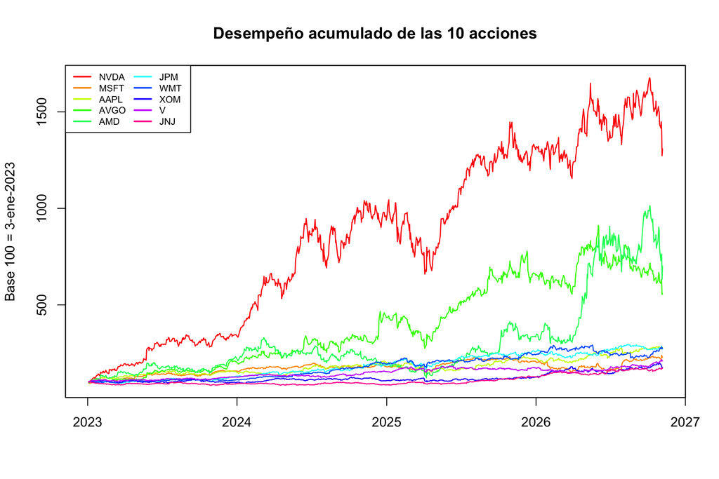

```r
indice <- xts(sweep(coredata(datos[, acciones]), 2, as.numeric(datos[1, acciones]), "/"),
              order.by = index(datos))
plot.zoo(indice * 100, plot.type = "single", col = rainbow(10), lwd = 1.3,
         xlab = "", ylab = "Base 100 = 3-ene-2023",
         main = "Desempeño acumulado de las 10 acciones")
legend("topleft", legend = acciones, col = rainbow(10), lwd = 2, cex = 0.7, ncol = 2)
```

**Interpretación:** NVDA tuvo el mayor rendimiento anualizado (67%), pero también una de las mayores volatilidades (47.5%), mientras que AMD es la más volátil (57%). JNJ y XOM tuvieron los rendimientos más bajos (alrededor de 14–15%) con volatilidades moderadas. La matriz de correlación muestra dos bloques: los semiconductores (NVDA, AVGO, AMD) se mueven juntos, con correlaciones de 0.51 a 0.61. En cambio, JNJ tiene correlación negativa con ellos (hasta −0.23 con NVDA), lo que indica que el portafolio sí tiene elementos de diversificación.

## 2.4 Regresión lineal simple: modelo de mercado

Se estima para cada acción:

$$r_{i,t} = \alpha_i + \beta_i \,
r_{SPX,t} + \varepsilon_{i,t}$$

- $\beta_i$ mide la sensibilidad de la acción al mercado: $\beta > 1$ indica una acción más riesgosa que el mercado y $\beta < 1$ una acción defensiva.
- $\alpha_i$ es el rendimiento diario no explicado por el mercado.
- Es una versión simplificada del CAPM, porque no se resta la tasa libre de riesgo (a nivel diario su efecto es muy pequeño).

```r
estrellas <- function(p) {
  ifelse(p < 0.001, "***", ifelse(p < 0.01, "**",
         ifelse(p < 0.05, "*", ifelse(p < 0.1, ".", ""))))
}

modelos_simples <- list()
tabla_capm <- data.frame()

for (s in acciones) {
  m  <- lm(as.formula(paste(s, "~ SPX")), data = df)
  cf <- summary(m)$coefficients
  modelos_simples[[s]] <- m
  tabla_capm <- rbind(tabla_capm, data.frame(
    Accion   = s,
    Alfa     = round(cf[1, 1], 5),
    p_alfa   = round(cf[1, 4], 3),
    Beta     = paste0(round(cf[2, 1], 3), estrellas(cf[2, 4])),
    t_beta   = round(cf[2, 3], 2),
    R2       = round(summary(m)$r.squared, 3)
  ))
}

tabla_capm <- tabla_capm[order(-as.numeric(gsub("[^0-9.-]", "", tabla_capm$Beta))), ]
kable(tabla_capm, row.names = FALSE,
      caption = "Modelo de mercado por acción (ordenado de mayor a menor beta)")
```

Modelo de mercado por acción (ordenado de mayor a menor beta)

| Accion | Alfa | p_alfa | Beta | t_beta | R2 |
| --- | --- | --- | --- | --- | --- |
| AMD | 0.00042 | 0.651 | 2.346*** | 23.48 | 0.364 |
| NVDA | 0.00124 | 0.091 | 2.095*** | 26.66 | 0.425 |
| AVGO | 0.00044 | 0.557 | 1.975*** | 24.78 | 0.389 |
| AAPL | 0.00034 | 0.409 | 1.058*** | 23.86 | 0.371 |
| MSFT | 0.00014 | 0.746 | 1.05*** | 22.66 | 0.348 |
| JPM | 0.00043 | 0.263 | 0.891*** | 21.70 | 0.328 |
| V | 0.00032 | 0.356 | 0.653*** | 17.43 | 0.240 |
| WMT | 0.00079 | 0.065 | 0.371*** | 8.08 | 0.064 |
| XOM | 0.00043 | 0.377 | 0.232*** | 4.47 | 0.020 |
| JNJ | 0.00052 | 0.159 | 0.06 | 1.50 | 0.002 |

Significancia: `***` p < 0.001, `**` p < 0.01, `*` p < 0.05, `.` p < 0.10.

**Interpretación general:** La beta es significativa al 0.1% (`***`) en 9 de las 10 acciones: hay menos de 0.1% de probabilidad de observar esa relación si en realidad no existiera. La excepción es JNJ, cuya beta (0.06) no es significativa ni siquiera al 10%, por lo que no podemos afirmar que dependa del mercado. Ninguna alfa es significativa al 5%; solo NVDA (p = 0.091) y WMT (p = 0.065) lo son al 10% (`.`), lo que es evidencia débil de un rendimiento extra no explicado por el mercado. El R² va de 0.2% (JNJ) a 42% (NVDA): el mercado explica buena parte de los semiconductores y casi nada de las acciones defensivas.

### 2.4.1 Análisis a fondo: NVDA, JNJ y WMT

Para las tres acciones seleccionadas se revisa el resumen completo del modelo, la prueba de si su beta es igual a 1 (es decir, si se mueve igual que el mercado) y los residuales.

**Prueba sobre beta:** $H_0: \beta = 1$ contra $H_1: \beta \neq 1$.

#### 2.4.1.1 NVDA

```r
summary(modelos_simples[["NVDA"]])
```

```
##
## Call:
## lm(formula = as.formula(paste(s, "~ SPX")), data = df)
##
## Residuals:
##       Min        1Q    Median        3Q       Max
## -0.156412 -0.012668 -0.000932  0.011548  0.198582
##
## Coefficients:
##              Estimate Std. Error t value            Pr(>|t|)
## (Intercept) 0.0012381  0.0007327    1.69              0.0914 .
## SPX         2.0950227  0.0785729   26.66 <0.0000000000000002 ***
## ---
## Signif. codes:  0 '***' 0.001 '**' 0.01 '*' 0.05 '.' 0.1 ' ' 1
##
## Residual standard error: 0.0227 on 963 degrees of freedom
## Multiple R-squared:  0.4247, Adjusted R-squared:  0.4241
## F-statistic: 710.9 on 1 and 963 DF,  p-value: < 0.00000000000000022
```

```r
linearHypothesis(modelos_simples[["NVDA"]], "SPX = 1")
```

```
##
## Linear hypothesis test:
## SPX = 1
##
## Model 1: restricted model
## Model 2: NVDA ~ SPX
##
##   Res.Df     RSS Df Sum of Sq      F                Pr(>F)
## 1    964 0.59633
## 2    963 0.49624  1   0.10008 194.22 < 0.00000000000000022 ***
## ---
## Signif. codes:  0 '***' 0.001 '**' 0.01 '*' 0.05 '.' 0.1 ' ' 1
```

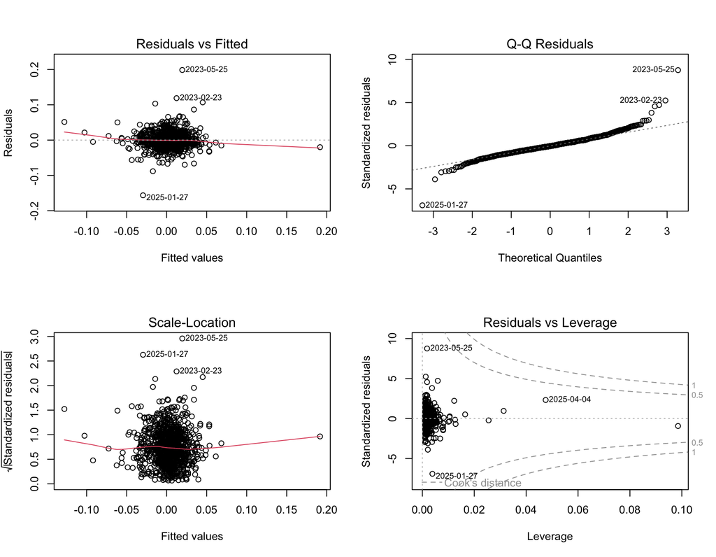

```r
par(mfrow = c(2, 2)); plot(modelos_simples[["NVDA"]]); par(mfrow = c(1, 1))
```

**Interpretación:** Su beta de 2.10 indica que, en promedio, si el S&P 500 sube 1%, NVDA sube 2.1%. La prueba de $H_0: \beta = 1$ da F = 194.2 con p < 0.001, así que se rechaza que se mueva igual que el mercado: es significativamente más riesgosa. La prueba F global (F = 710.9) es muy alta porque, con una sola variable explicativa, equivale a la prueba t al cuadrado (26.66² ≈ 711). Los residuales se distribuyen alrededor de cero sin patrón, pero el Q-Q plot muestra colas pesadas por eventos extremos (25-may-2023 y 27-ene-2025). Con 965 observaciones la inferencia sigue siendo razonable, pero el riesgo de saltos bruscos es alto.

#### 2.4.1.2 JNJ

```r
summary(modelos_simples[["JNJ"]])
```

```
##
## Call:
## lm(formula = as.formula(paste(s, "~ SPX")), data = df)
##
## Residuals:
##       Min        1Q    Median        3Q       Max
## -0.079704 -0.005774 -0.000100  0.006226  0.059374
##
## Coefficients:
##              Estimate Std. Error t value Pr(>|t|)
## (Intercept) 0.0005245  0.0003723   1.409    0.159
## SPX         0.0599260  0.0399267   1.501    0.134
##
## Residual standard error: 0.01154 on 963 degrees of freedom
## Multiple R-squared:  0.002334,   Adjusted R-squared:  0.001298
## F-statistic: 2.253 on 1 and 963 DF,  p-value: 0.1337
```

```r
linearHypothesis(modelos_simples[["JNJ"]], "SPX = 1")
```

```
##
## Linear hypothesis test:
## SPX = 1
##
## Model 1: restricted model
## Model 2: JNJ ~ SPX
##
##   Res.Df     RSS Df Sum of Sq      F                Pr(>F)
## 1    964 0.20190
## 2    963 0.12814  1  0.073764 554.37 < 0.00000000000000022 ***
## ---
## Signif. codes:  0 '***' 0.001 '**' 0.01 '*' 0.05 '.' 0.1 ' ' 1
```

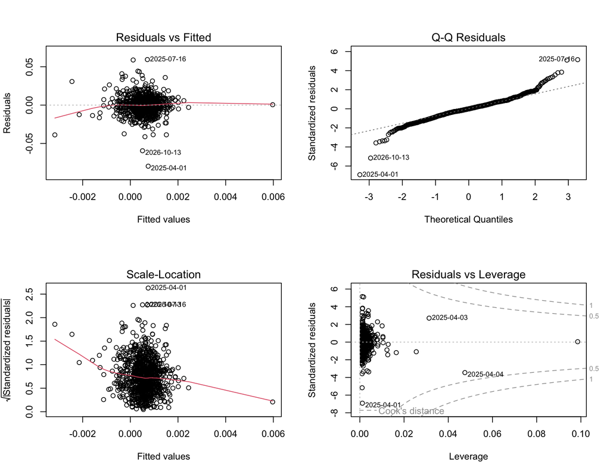

```r
par(mfrow = c(2, 2)); plot(modelos_simples[["JNJ"]]); par(mfrow = c(1, 1))
```

**Interpretación:** La beta de 0.06 no es significativa (p = 0.134), así que no se rechaza $H_0: \beta = 0$: el mercado no explica a JNJ (R² = 0.2%). La prueba de $H_0: \beta = 1$ sí se rechaza con fuerza (F = 554.4), lo que confirma que JNJ es claramente menos riesgosa que el mercado. Sus residuales extremos coinciden con eventos propios de la empresa (abril de 2025 y su reporte de octubre de 2026) y no con movimientos del mercado. Esto indica que su riesgo es idiosincrático y que funciona como cobertura dentro del portafolio.

#### 2.4.1.3 WMT

```r
summary(modelos_simples[["WMT"]])
```

```
##
## Call:
## lm(formula = as.formula(paste(s, "~ SPX")), data = df)
##
## Residuals:
##       Min        1Q    Median        3Q       Max
## -0.093532 -0.006529  0.000202  0.006702  0.067642
##
## Coefficients:
##              Estimate Std. Error t value            Pr(>|t|)
## (Intercept) 0.0007906  0.0004285   1.845              0.0653 .
## SPX         0.3714734  0.0459505   8.084 0.00000000000000187 ***
## ---
## Signif. codes:  0 '***' 0.001 '**' 0.01 '*' 0.05 '.' 0.1 ' ' 1
##
## Residual standard error: 0.01328 on 963 degrees of freedom
## Multiple R-squared:  0.06355,    Adjusted R-squared:  0.06258
## F-statistic: 65.35 on 1 and 963 DF,  p-value: 0.000000000000001868
```

```r
linearHypothesis(modelos_simples[["WMT"]], "SPX = 1")
```

```
##
## Linear hypothesis test:
## SPX = 1
##
## Model 1: restricted model
## Model 2: WMT ~ SPX
##
##   Res.Df     RSS Df Sum of Sq     F                Pr(>F)
## 1    964 0.20269
## 2    963 0.16972  1  0.032974 187.1 < 0.00000000000000022 ***
## ---
## Signif. codes:  0 '***' 0.001 '**' 0.01 '*' 0.05 '.' 0.1 ' ' 1
```

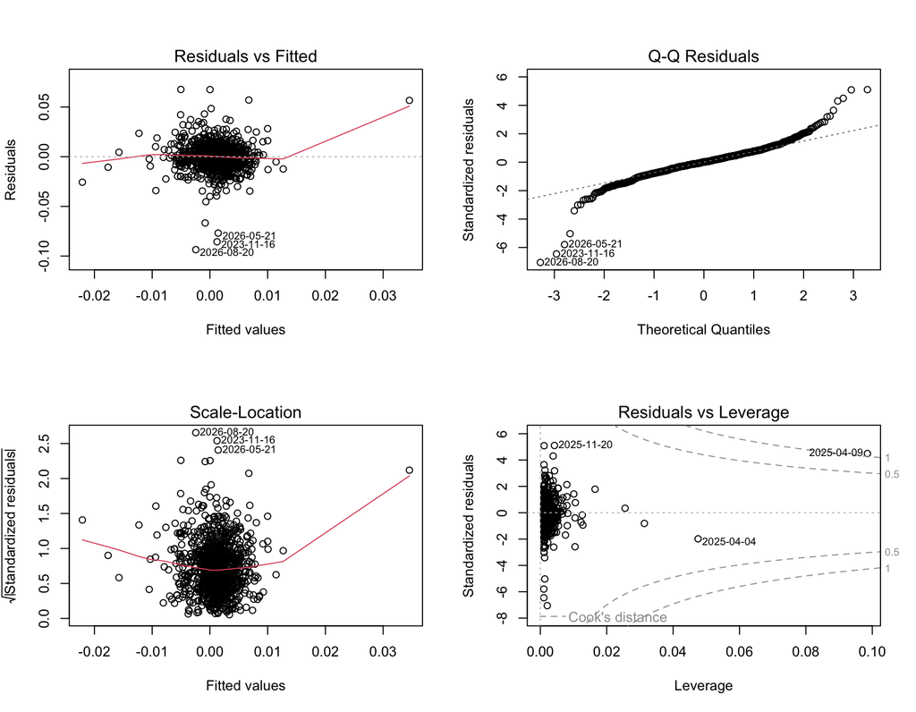

```r
par(mfrow = c(2, 2)); plot(modelos_simples[["WMT"]]); par(mfrow = c(1, 1))
```

**Interpretación:** La beta de 0.37 es significativa al 0.1%, pero está muy por debajo de 1 ($H_0: \beta = 1$ se rechaza con F = 187.1). Por cada 1% que se mueve el mercado, WMT se mueve en promedio 0.37%, lo que confirma su perfil defensivo. El R² de 6% indica que el 94% de su variación proviene de factores propios de la empresa. Su alfa es marginalmente significativa al 10% (p = 0.065), una señal débil de desempeño superior al esperado por su nivel de riesgo.

## 2.5 Regresión lineal múltiple

Se agrega al modelo de mercado el efecto de tres variables macro-financieras:

$$r_{i,t} = \beta_0 + \beta_1 r_{SPX,t} +
\beta_2 \Delta VIX_t + \beta_3 \Delta TNX_t + \beta_4 \Delta DXY_t +
\varepsilon_{i,t}$$

- **ΔVIX:** cambios en la aversión al riesgo del mercado.
- **ΔTNX:** cambios en la tasa de interés de largo plazo.
- **ΔDXY:** cambios en la fortaleza del dólar.

**Prueba F de significancia global:** $H_0: \beta_1 = \beta_2 = \beta_3 = \beta_4 = 0$ (ninguna variable explica el rendimiento) contra $H_1$: al menos un $\beta_j \neq 0$.

```r
modelos_multiples <- list()
tabla_mult <- data.frame()

for (s in acciones) {
  m  <- lm(as.formula(paste(s, "~ SPX + dVIX + dTNX + dDXY")), data = df)
  sm <- summary(m)
  cf <- sm$coefficients
  f  <- sm$fstatistic
  modelos_multiples[[s]] <- m
  tabla_mult <- rbind(tabla_mult, data.frame(
    Accion  = s,
    SPX     = paste0(round(cf[2, 1], 3), estrellas(cf[2, 4])),
    dVIX    = paste0(round(cf[3, 1], 4), estrellas(cf[3, 4])),
    dTNX    = paste0(round(cf[4, 1], 4), estrellas(cf[4, 4])),
    dDXY    = paste0(round(cf[5, 1], 3), estrellas(cf[5, 4])),
    R2_aj   = round(sm$adj.r.squared, 3),
    F       = round(f[1], 1),
    p_F     = signif(pf(f[1], f[2], f[3], lower.tail = FALSE), 3)
  ))
}

kable(tabla_mult, row.names = FALSE,
      caption = "Regresión múltiple por acción (coeficientes y significancia)")
```

Regresión múltiple por acción (coeficientes y significancia)

| Accion | SPX | dVIX | dTNX | dDXY | R2_aj | F | p_F |
| --- | --- | --- | --- | --- | --- | --- | --- |
| NVDA | 2.369*** | 0.0017* | 0.0392** | 0.077 | 0.431 | 183.9 | 0.0000000 |
| MSFT | 1.247*** | 0.0013** | 0.0193* | -0.049 | 0.354 | 133.3 | 0.0000000 |
| AAPL | 0.971*** | -0.0006 | -0.0109 | 0.108 | 0.371 | 143.4 | 0.0000000 |
| AVGO | 2.291*** | 0.002** | 0.0315* | 0.063 | 0.395 | 158.5 | 0.0000000 |
| AMD | 2.672*** | 0.0021* | 0.0276 | -0.06 | 0.366 | 140.2 | 0.0000000 |
| JPM | 0.704*** | -0.0012*** | 0.0323*** | 0.052 | 0.355 | 133.5 | 0.0000000 |
| WMT | 0.338*** | -0.0003 | -0.0148. | 0.158 | 0.064 | 17.3 | 0.0000000 |
| XOM | 0.094 | -0.0009. | 0.0509*** | -0.12 | 0.056 | 15.4 | 0.0000000 |
| V | 0.524*** | -0.0008* | -0.0083 | 0.08 | 0.243 | 78.2 | 0.0000000 |
| JNJ | -0.038 | -0.0006 | -0.025*** | -0.13 | 0.022 | 6.5 | 0.0000356 |

### 2.5.1 ¿La regresión múltiple mejora al modelo simple?

Prueba F de modelos anidados: $H_0$: las tres variables agregadas (ΔVIX, ΔTNX, ΔDXY) no aportan poder explicativo ($\beta_2 = \beta_3 = \beta_4 = 0$).

```r
tabla_anidados <- data.frame()
for (s in acciones) {
  a <- anova(modelos_simples[[s]], modelos_multiples[[s]])
  tabla_anidados <- rbind(tabla_anidados, data.frame(
    Accion      = s,
    R2_simple   = round(summary(modelos_simples[[s]])$r.squared, 3),
    R2_multiple = round(summary(modelos_multiples[[s]])$r.squared, 3),
    F           = round(a$F[2], 2),
    p_valor     = signif(a$`Pr(>F)`[2], 3),
    Conclusion  = ifelse(a$`Pr(>F)`[2] < 0.05, "Mejora (se rechaza H0)", "No mejora")
  ))
}
kable(tabla_anidados, row.names = FALSE,
      caption = "Comparación modelo simple vs. múltiple")
```

Comparación modelo simple vs. múltiple

| Accion | R2_simple | R2_multiple | F | p_valor | Conclusion |
| --- | --- | --- | --- | --- | --- |
| NVDA | 0.425 | 0.434 | 5.16 | 0.0015200 | Mejora (se rechaza H0) |
| MSFT | 0.348 | 0.357 | 4.65 | 0.0031200 | Mejora (se rechaza H0) |
| AAPL | 0.371 | 0.374 | 1.31 | 0.2690000 | No mejora |
| AVGO | 0.389 | 0.398 | 4.44 | 0.0041500 | Mejora (se rechaza H0) |
| AMD | 0.364 | 0.369 | 2.45 | 0.0625000 | No mejora |
| JPM | 0.328 | 0.357 | 14.46 | 0.0000000 | Mejora (se rechaza H0) |
| WMT | 0.064 | 0.067 | 1.32 | 0.2680000 | No mejora |
| XOM | 0.020 | 0.060 | 13.59 | 0.0000000 | Mejora (se rechaza H0) |
| V | 0.240 | 0.246 | 2.50 | 0.0580000 | No mejora |
| JNJ | 0.002 | 0.026 | 7.92 | 0.0000319 | Mejora (se rechaza H0) |

**Interpretación:** La prueba F de modelos anidados rechaza $H_0$ en 6 de 10 acciones (NVDA, MSFT, AVGO, JPM, XOM y JNJ): en ellas, VIX, tasas y dólar sí aportan información adicional. Las mejoras de R² son pequeñas (de 0.3 a 4 puntos), pero relevantes en XOM (de 2% a 6%) y JNJ (de 0.2% a 2.6%). En AAPL, AMD, WMT y V basta el modelo simple de mercado.

### 2.5.2 Diagnóstico a fondo: NVDA, JNJ y WMT

Para cada modelo se revisa:

- **VIF (multicolinealidad):** valores mayores a 5 indican que las variables explicativas están muy relacionadas entre sí.
- **Breusch-Pagan (heterocedasticidad):** $H_0$: la varianza de los residuales es constante.
- **Durbin-Watson (autocorrelación):** $H_0$: los residuales no están autocorrelacionados.
- **Errores robustos:** si hay heterocedasticidad, se recalcula la significancia con errores estándar robustos (HC1) para que las conclusiones sean confiables.

```r
diagnostico <- function(s) {
  m <- modelos_multiples[[s]]
  cat("\n==========", s, "==========\n")
  print(summary(m))
  cat("\n--- VIF ---\n");                       print(round(vif(m), 2))
  cat("\n--- Breusch-Pagan ---\n");             print(bptest(m))
  cat("\n--- Durbin-Watson ---\n");             print(dwtest(m))
  cat("\n--- Coeficientes con errores robustos (HC1) ---\n")
  print(coeftest(m, vcov = vcovHC(m, type = "HC1")))
}
```

#### 2.5.2.1 NVDA

```r
diagnostico("NVDA")
```

```
##
## ========== NVDA ==========
##
## Call:
## lm(formula = as.formula(paste(s, "~ SPX + dVIX + dTNX + dDXY")),
##     data = df)
##
## Residuals:
##      Min       1Q   Median       3Q      Max
## -0.15350 -0.01227 -0.00112  0.01151  0.19400
##
## Coefficients:
##              Estimate Std. Error t value             Pr(>|t|)
## (Intercept) 0.0010050  0.0007324   1.372              0.17031
## SPX         2.3691216  0.1358810  17.435 < 0.0000000000000002 ***
## dVIX        0.0017227  0.0007119   2.420              0.01572 *
## dTNX        0.0391664  0.0138048   2.837              0.00465 **
## dDXY        0.0772551  0.1992281   0.388              0.69827
## ---
## Signif. codes:  0 '***' 0.001 '**' 0.01 '*' 0.05 '.' 0.1 ' ' 1
##
## Residual standard error: 0.02255 on 960 degrees of freedom
## Multiple R-squared:  0.4338, Adjusted R-squared:  0.4315
## F-statistic: 183.9 on 4 and 960 DF,  p-value: < 0.00000000000000022
##
##
## --- VIF ---
##  SPX dVIX dTNX dDXY
## 3.03 3.02 1.23 1.24
##
## --- Breusch-Pagan ---
##
##  studentized Breusch-Pagan test
##
## data:  m
## BP = 0.40914, df = 4, p-value = 0.9817
##
##
## --- Durbin-Watson ---
##
##  Durbin-Watson test
##
## data:  m
## DW = 2.1113, p-value = 0.9587
## alternative hypothesis: true autocorrelation is greater than 0
##
##
## --- Coeficientes con errores robustos (HC1) ---
##
## t test of coefficients:
##
##               Estimate Std. Error t value              Pr(>|t|)
## (Intercept) 0.00100503 0.00073035  1.3761              0.169116
## SPX         2.36912161 0.15277771 15.5070 < 0.00000000000000022 ***
## dVIX        0.00172265 0.00079569  2.1650              0.030635 *
## dTNX        0.03916643 0.01479204  2.6478              0.008234 **
## dDXY        0.07725509 0.18443924  0.4189              0.675409
## ---
## Signif. codes:  0 '***' 0.001 '**' 0.01 '*' 0.05 '.' 0.1 ' ' 1
```

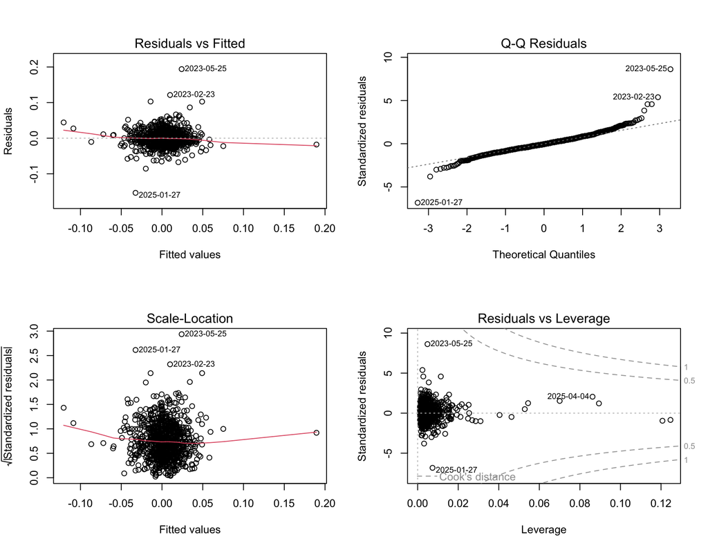

```r
par(mfrow = c(2, 2)); plot(modelos_multiples[["NVDA"]]); par(mfrow = c(1, 1))
```

**Interpretación:** Los VIF de SPX y VIX (alrededor de 3) muestran correlación moderada entre ellas, pero por debajo de 5, así que la multicolinealidad no es grave. Breusch-Pagan (p = 0.98) no rechaza varianza constante y Durbin-Watson (2.11, p = 0.96) no muestra autocorrelación, por lo que los supuestos se cumplen. Al subir la tasa a 10 años un punto porcentual, NVDA sube en promedio 3.9% (significativo al 1%, `**`), un efecto atípico para tecnología que refleja su crecimiento en periodos de economía fuerte. Los errores robustos confirman las mismas conclusiones.

#### 2.5.2.2 JNJ

```r
diagnostico("JNJ")
```

```
##
## ========== JNJ ==========
##
## Call:
## lm(formula = as.formula(paste(s, "~ SPX + dVIX + dTNX + dDXY")),
##     data = df)
##
## Residuals:
##       Min        1Q    Median        3Q       Max
## -0.081913 -0.005797  0.000003  0.006151  0.061789
##
## Coefficients:
##               Estimate Std. Error t value Pr(>|t|)
## (Intercept)  0.0006179  0.0003706   1.667 0.095805 .
## SPX         -0.0384377  0.0687568  -0.559 0.576266
## dVIX        -0.0005860  0.0003602  -1.627 0.104152
## dTNX        -0.0250049  0.0069853  -3.580 0.000361 ***
## dDXY        -0.1301983  0.1008110  -1.292 0.196838
## ---
## Signif. codes:  0 '***' 0.001 '**' 0.01 '*' 0.05 '.' 0.1 ' ' 1
##
## Residual standard error: 0.01141 on 960 degrees of freedom
## Multiple R-squared:  0.02644,    Adjusted R-squared:  0.02238
## F-statistic: 6.517 on 4 and 960 DF,  p-value: 0.0000356
##
##
## --- VIF ---
##  SPX dVIX dTNX dDXY
## 3.03 3.02 1.23 1.24
##
## --- Breusch-Pagan ---
##
##  studentized Breusch-Pagan test
##
## data:  m
## BP = 10.468, df = 4, p-value = 0.03324
##
##
## --- Durbin-Watson ---
##
##  Durbin-Watson test
##
## data:  m
## DW = 2.0366, p-value = 0.7175
## alternative hypothesis: true autocorrelation is greater than 0
##
##
## --- Coeficientes con errores robustos (HC1) ---
##
## t test of coefficients:
##
##                Estimate  Std. Error t value  Pr(>|t|)
## (Intercept)  0.00061786  0.00038056  1.6236 0.1047960
## SPX         -0.03843767  0.06666052 -0.5766 0.5643325
## dVIX        -0.00058597  0.00039764 -1.4736 0.1409108
## dTNX        -0.02500487  0.00749303 -3.3371 0.0008791 ***
## dDXY        -0.13019830  0.10772837 -1.2086 0.2271220
## ---
## Signif. codes:  0 '***' 0.001 '**' 0.01 '*' 0.05 '.' 0.1 ' ' 1
```

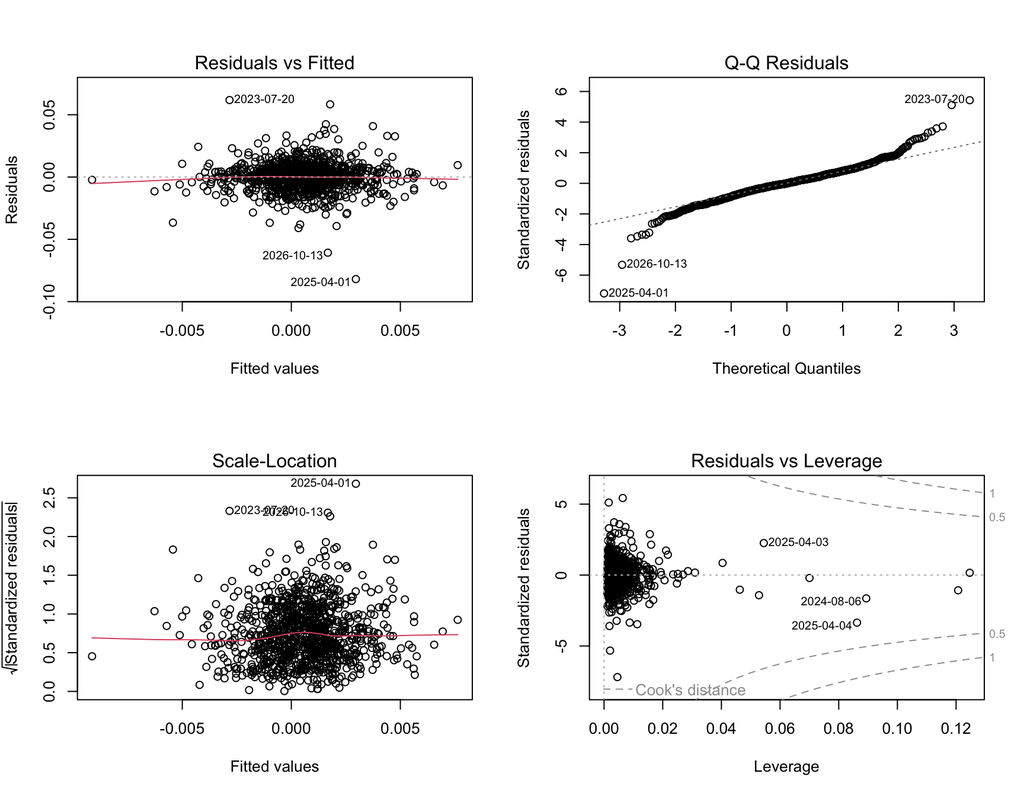

```r
par(mfrow = c(2, 2)); plot(modelos_multiples[["JNJ"]]); par(mfrow = c(1, 1))
```

**Interpretación:** El hallazgo clave es que la tasa a 10 años es la única variable significativa (al 0.1%): si sube un punto porcentual, JNJ cae 2.5% en promedio, porque su flujo estable y su dividendo la hacen comportarse como un bono. Breusch-Pagan sí rechaza varianza constante al 5% (p = 0.033), es decir, hay heterocedasticidad. Con errores robustos (HC1) la tasa sigue siendo significativa (p < 0.001), así que la conclusión es confiable. Durbin-Watson (2.04) no muestra autocorrelación.

#### 2.5.2.3 WMT

```r
diagnostico("WMT")
```

```
##
## ========== WMT ==========
##
## Call:
## lm(formula = as.formula(paste(s, "~ SPX + dVIX + dTNX + dDXY")),
##     data = df)
##
## Residuals:
##       Min        1Q    Median        3Q       Max
## -0.093067 -0.006640  0.000151  0.006752  0.067538
##
## Coefficients:
##               Estimate Std. Error t value  Pr(>|t|)
## (Intercept)  0.0008341  0.0004309   1.936    0.0532 .
## SPX          0.3376382  0.0799394   4.224 0.0000263 ***
## dVIX        -0.0002504  0.0004188  -0.598    0.5501
## dTNX        -0.0147519  0.0081214  -1.816    0.0696 .
## dDXY         0.1579152  0.1172068   1.347    0.1782
## ---
## Signif. codes:  0 '***' 0.001 '**' 0.01 '*' 0.05 '.' 0.1 ' ' 1
##
## Residual standard error: 0.01327 on 960 degrees of freedom
## Multiple R-squared:  0.06739,    Adjusted R-squared:  0.0635
## F-statistic: 17.34 on 4 and 960 DF,  p-value: 0.00000000000009536
##
##
## --- VIF ---
##  SPX dVIX dTNX dDXY
## 3.03 3.02 1.23 1.24
##
## --- Breusch-Pagan ---
##
##  studentized Breusch-Pagan test
##
## data:  m
## BP = 1.1647, df = 4, p-value = 0.8839
##
##
## --- Durbin-Watson ---
##
##  Durbin-Watson test
##
## data:  m
## DW = 1.9277, p-value = 0.1317
## alternative hypothesis: true autocorrelation is greater than 0
##
##
## --- Coeficientes con errores robustos (HC1) ---
##
## t test of coefficients:
##
##                Estimate  Std. Error t value   Pr(>|t|)
## (Intercept)  0.00083414  0.00043476  1.9186    0.05533 .
## SPX          0.33763818  0.07704095  4.3826 0.00001302 ***
## dVIX        -0.00025040  0.00045701 -0.5479    0.58388
## dTNX        -0.01475190  0.00826624 -1.7846    0.07464 .
## dDXY         0.15791521  0.11731464  1.3461    0.17859
## ---
## Signif. codes:  0 '***' 0.001 '**' 0.01 '*' 0.05 '.' 0.1 ' ' 1
```

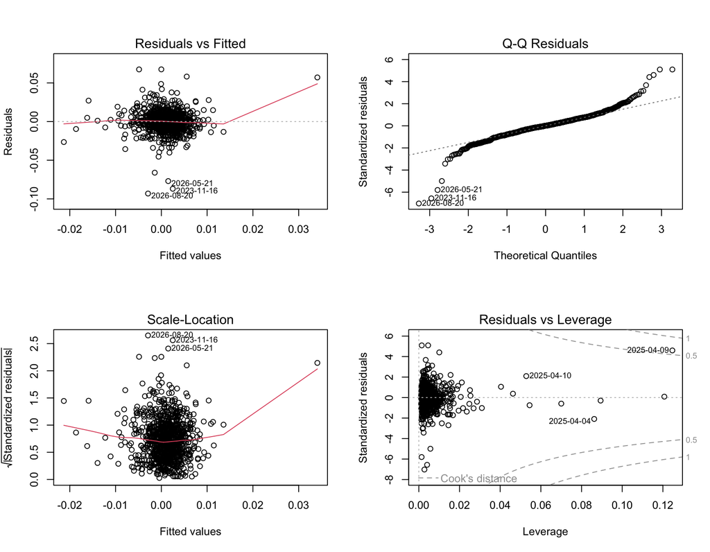

```r
par(mfrow = c(2, 2)); plot(modelos_multiples[["WMT"]]); par(mfrow = c(1, 1))
```

**Interpretación:** Solo el S&P 500 es significativo al 0.1%; la tasa lo es apenas al 10% (`.`) y con signo negativo. Breusch-Pagan (p = 0.88) y Durbin-Watson (1.93) no muestran problemas, y los VIF están por debajo de 5. La prueba de modelos anidados (p = 0.27) indica que agregar VIX, tasas y dólar no mejora el modelo: para WMT basta el modelo de mercado.

# 3 Parte 2. Datos panel trimestral

## 3.1 Objetivo

Estimar con datos panel si el **riesgo** (volatilidad) y el **interés del mercado** (volumen) de cada acción en un trimestre anticipan su rendimiento en el trimestre siguiente, controlando por el movimiento del mercado y de las tasas de interés.

**Nota metodológica:** el panel se construye con datos de mercado trimestrales obtenidos de Yahoo Finance (rendimiento, volatilidad y volumen), no con estados financieros. Se eligió así para tener una fuente homogénea y trimestres calendario comparables entre empresas con años fiscales distintos (NVDA y WMT cierran en enero, MSFT en junio, AAPL y V en septiembre).

## 3.2 Paquetes

```r
paquetes <- c("quantmod", "plm", "lmtest", "sandwich", "knitr")
faltan <- paquetes[!paquetes %in% installed.packages()[, "Package"]]
if (length(faltan) > 0) install.packages(faltan)

library(quantmod)   # descarga de Yahoo Finance
library(plm)        # modelos de datos panel
library(lmtest)     # coeftest
library(sandwich)   # errores robustos
library(knitr)      # tablas
```

## 3.3 Construcción del panel

- **Unidades:** 10 acciones.
- **Periodo:** 2023Q1 a 2026Q3 (15 trimestres). Se descarga desde 2022Q4 para calcular el rezago del primer trimestre; 2026Q4 se excluye por estar incompleto.

**Variables:**

| Variable | Definición |
| --- | --- |
| `Rend` | Rendimiento logarítmico trimestral de la acción (suma de rendimientos diarios) |
| `Vol_lag` | Volatilidad anualizada de la acción en el trimestre **anterior** |
| `LogVolumen_lag` | Logaritmo del volumen diario promedio en el trimestre **anterior** |
| `Rend_SPX` | Rendimiento logarítmico trimestral del S&P 500 |
| `dTNX` | Cambio trimestral de la tasa del Treasury a 10 años (puntos porcentuales) |

```r
acciones <- c("NVDA", "MSFT", "AAPL", "AVGO", "AMD",
              "JPM", "WMT", "XOM", "V", "JNJ")
inicio <- "2022-10-01"
fin    <- "2026-10-01"   # excluye 2026Q4 (incompleto)

bajar <- function(simbolo) {
  bajar_guardado(simbolo, inicio, fin)
}

trimestre <- function(x) as.character(as.yearqtr(index(x)))

# --- Variables por acción ---
panel <- data.frame()
for (s in acciones) {
  x <- bajar(s)
  r <- diff(log(Ad(x)))
  rq   <- apply.quarterly(r, function(z) sum(z, na.rm = TRUE))
  volq <- apply.quarterly(r, function(z) sd(z, na.rm = TRUE) * sqrt(252))
  vq   <- apply.quarterly(Vo(x), function(z) mean(z, na.rm = TRUE))
  panel <- rbind(panel, data.frame(
    Accion     = s,
    Trimestre  = trimestre(rq),
    Rend       = as.numeric(rq),
    Vol        = as.numeric(volq),
    LogVolumen = log(as.numeric(vq))
  ))
}

# --- Variables de mercado (iguales para todas las acciones en cada trimestre) ---
spx  <- diff(log(Ad(bajar("^GSPC"))))
spxq <- apply.quarterly(spx, function(z) sum(z, na.rm = TRUE))

tnx  <- na.omit(Cl(bajar("^TNX")))
tnxq <- tnx[endpoints(tnx, on = "quarters")]   # nivel al cierre de cada trimestre
dtnx <- diff(tnxq)

mercado <- merge(
  data.frame(Trimestre = trimestre(spxq), Rend_SPX = as.numeric(spxq)),
  data.frame(Trimestre = trimestre(dtnx), dTNX = as.numeric(dtnx)),
  by = "Trimestre"
)

panel <- merge(panel, mercado, by = "Trimestre")
panel <- panel[order(panel$Accion, panel$Trimestre), ]

# --- Rezagos dentro de cada acción ---
rezagar <- function(z) c(NA, head(z, -1))
panel$Vol_lag        <- ave(panel$Vol,        panel$Accion, FUN = rezagar)
panel$LogVolumen_lag <- ave(panel$LogVolumen, panel$Accion, FUN = rezagar)

# --- Muestra final: 2023Q1 a 2026Q3 ---
panel <- panel[panel$Trimestre >= "2023 Q1" & !is.na(panel$Vol_lag), ]
rownames(panel) <- NULL

dim(panel)
```

```
## [1] 150   9
```

```r
table(panel$Accion)
```

```
##
## AAPL  AMD AVGO  JNJ  JPM MSFT NVDA    V  WMT  XOM
##   15   15   15   15   15   15   15   15   15   15
```

```r
head(panel)
```

```
##   Trimestre Accion       Rend       Vol LogVolumen    Rend_SPX       dTNX
## 1   2023 Q1   AAPL  0.2398691 0.2424623   18.04801  0.06791300 -0.3850000
## 2   2023 Q2   AAPL  0.1637465 0.1816110   17.86097  0.07973431  0.3250000
## 3   2023 Q3   AAPL -0.1234631 0.2141023   17.87666 -0.03715742  0.7539999
## 4   2023 Q4   AAPL  0.1186777 0.1556583   17.78480  0.10647864 -0.7070000
## 5   2024 Q1   AAPL -0.1145102 0.2110688   17.94270  0.09674564  0.3399999
## 6   2024 Q2   AAPL  0.2069444 0.2689031   18.03889  0.03848037  0.1370001
##     Vol_lag LogVolumen_lag
## 1 0.3979926       18.24192
## 2 0.2424623       18.04801
## 3 0.1816110       17.86097
## 4 0.2141023       17.87666
## 5 0.1556583       17.78480
## 6 0.2110688       17.94270
```

## 3.4 Estadística descriptiva

```r
vars <- c("Rend", "Vol_lag", "LogVolumen_lag", "Rend_SPX", "dTNX")
desc <- data.frame(
  Variable = vars,
  Media    = round(sapply(panel[, vars], mean), 4),
  Desv_Est = round(sapply(panel[, vars], sd), 4),
  Minimo   = round(sapply(panel[, vars], min), 4),
  Maximo   = round(sapply(panel[, vars], max), 4)
)
kable(desc, row.names = FALSE, caption = "Estadística descriptiva del panel")
```

Estadística descriptiva del panel

| Variable | Media | Desv_Est | Minimo | Maximo |
| --- | --- | --- | --- | --- |
| Rend | 0.0804 | 0.1747 | -0.3225 | 1.0493 |
| Vol_lag | 0.3008 | 0.1524 | 0.1140 | 0.7781 |
| LogVolumen_lag | 17.0510 | 1.1079 | 15.4679 | 20.1064 |
| Rend_SPX | 0.0460 | 0.0559 | -0.0474 | 0.1386 |
| dTNX | 0.0943 | 0.4579 | -0.7070 | 0.8750 |

```r
prom <- aggregate(cbind(Rend, Vol_lag) ~ Accion, data = panel, FUN = mean)
prom[, 2:3] <- round(prom[, 2:3], 3)
kable(prom, caption = "Promedios por acción (rendimiento trimestral y volatilidad)")
```

Promedios por acción (rendimiento trimestral y volatilidad)

| Accion | Rend | Vol_lag |
| --- | --- | --- |
| AAPL | 0.064 | 0.254 |
| AMD | 0.150 | 0.540 |
| AVGO | 0.126 | 0.450 |
| JNJ | 0.034 | 0.170 |
| JPM | 0.066 | 0.230 |
| MSFT | 0.053 | 0.254 |
| NVDA | 0.183 | 0.477 |
| V | 0.038 | 0.194 |
| WMT | 0.055 | 0.204 |
| XOM | 0.034 | 0.236 |

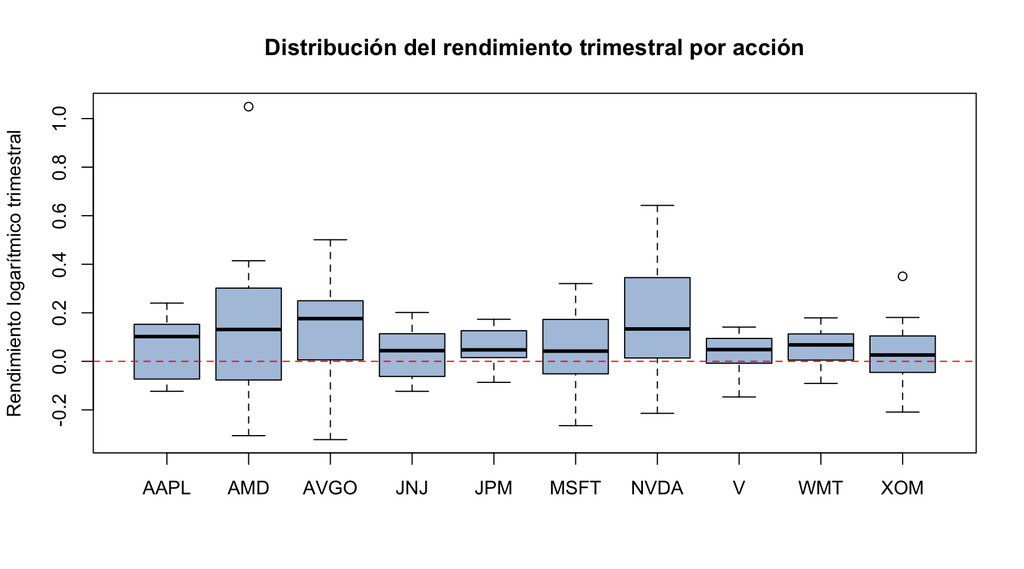

```r
boxplot(Rend ~ Accion, data = panel, col = "lightsteelblue",
        main = "Distribución del rendimiento trimestral por acción",
        ylab = "Rendimiento logarítmico trimestral", xlab = "")
abline(h = 0, lty = 2, col = "red")
```

**Interpretación:** El rendimiento trimestral promedio fue de 8%, con alta dispersión (desviación estándar de 17.5%) y un trimestre extremo con rendimiento logarítmico de 1.05. NVDA (18.3%), AMD (15%) y AVGO (12.6%) tuvieron los mayores rendimientos promedio y también las mayores volatilidades (45–54% anual). JNJ, XOM y V tuvieron los rendimientos más bajos (3–4%) con volatilidades menores (17–24%). La gráfica de cajas muestra que los semiconductores tienen distribuciones mucho más amplias, lo que anticipa una relación entre riesgo y rendimiento entre acciones.

## 3.5 Modelos de datos panel

$$Rend_{i,t} = \beta_0 + \beta_1
Vol_{i,t-1} + \beta_2 LogVolumen_{i,t-1} + \beta_3 Rend\_SPX_t + \beta_4
\Delta TNX_t + u_{i,t}$$

Se estiman tres modelos:

- **Pooled (MCO agrupado):** trata todas las observaciones como una sola muestra y supone que todas las acciones comparten el mismo intercepto.
- **Efectos fijos (within):** permite un intercepto propio para cada acción, que captura características constantes de cada empresa (sector, tamaño, modelo de negocio).
- **Efectos aleatorios:** supone que esas diferencias entre empresas son aleatorias y no están correlacionadas con las variables explicativas.

```r
pdat <- pdata.frame(panel, index = c("Accion", "Trimestre"))
formula_panel <- Rend ~ Vol_lag + LogVolumen_lag + Rend_SPX + dTNX

m_pool <- plm(formula_panel, data = pdat, model = "pooling")
m_fe   <- plm(formula_panel, data = pdat, model = "within")
# Si el método estándar (Swamy-Arora) estima una varianza negativa con muestras chicas,
# se usa el método de Wallace-Hussain como alternativa.
m_re <- tryCatch(plm(formula_panel, data = pdat, model = "random"),
                 error = function(e) plm(formula_panel, data = pdat, model = "random",
                                         random.method = "walhus"))
```

### 3.5.1 Modelo pooled

```r
summary(m_pool)
```

```
## Pooling Model
##
## Call:
## plm(formula = formula_panel, data = pdat, model = "pooling")
##
## Balanced Panel: n = 10, T = 15, N = 150
##
## Residuals:
##     Min.  1st Qu.   Median  3rd Qu.     Max.
## -0.43288 -0.08695 -0.00211  0.07981  0.76556
##
## Coefficients:
##                  Estimate Std. Error t-value    Pr(>|t|)
## (Intercept)    -0.3579084  0.2344862 -1.5264     0.12910
## Vol_lag         0.2473794  0.1081850  2.2866     0.02367 *
## LogVolumen_lag  0.0182152  0.0148541  1.2263     0.22209
## Rend_SPX        1.1399589  0.2383953  4.7818 0.000004225 ***
## dTNX            0.0093145  0.0291278  0.3198     0.74960
## ---
## Signif. codes:  0 '***' 0.001 '**' 0.01 '*' 0.05 '.' 0.1 ' ' 1
##
## Total Sum of Squares:    4.5453
## Residual Sum of Squares: 3.4965
## R-Squared:      0.23074
## Adj. R-Squared: 0.20952
## F-statistic: 10.8732 on 4 and 145 DF, p-value: 0.000000097499
```

### 3.5.2 Modelo de efectos fijos

```r
summary(m_fe)
```

```
## Oneway (individual) effect Within Model
##
## Call:
## plm(formula = formula_panel, data = pdat, model = "within")
##
## Balanced Panel: n = 10, T = 15, N = 150
##
## Residuals:
##     Min.  1st Qu.   Median  3rd Qu.     Max.
## -0.42811 -0.08121 -0.00644  0.07708  0.79058
##
## Coefficients:
##                Estimate Std. Error t-value   Pr(>|t|)
## Vol_lag        0.180372   0.167945  1.0740     0.2847
## LogVolumen_lag 0.054324   0.062960  0.8628     0.3897
## Rend_SPX       1.111109   0.252827  4.3947 0.00002216 ***
## dTNX           0.010289   0.030037  0.3425     0.7325
## ---
## Signif. codes:  0 '***' 0.001 '**' 0.01 '*' 0.05 '.' 0.1 ' ' 1
##
## Total Sum of Squares:    4.1641
## Residual Sum of Squares: 3.4571
## R-Squared:      0.16978
## Adj. R-Squared: 0.090419
## F-statistic: 6.95293 on 4 and 136 DF, p-value: 0.000040147
```

Interceptos (efectos fijos) de cada acción:

```r
kable(data.frame(Efecto_fijo = round(fixef(m_fe), 4)),
      caption = "Intercepto propio de cada acción (efectos fijos)")
```

Intercepto propio de cada acción (efectos fijos)

|  | Efecto_fijo |
| --- | --- |
| AAPL | -1.0041 |
| AMD | -0.9649 |
| AVGO | -0.9373 |
| JNJ | -0.9143 |
| JPM | -0.9021 |
| MSFT | -0.9710 |
| NVDA | -1.0173 |
| V | -0.9019 |
| WMT | -0.9439 |
| XOM | -0.9653 |

### 3.5.3 Modelo de efectos aleatorios

```r
summary(m_re)
```

```
## Oneway (individual) effect Random Effect Model
##    (Swamy-Arora's transformation)
##
## Call:
## plm(formula = formula_panel, data = pdat, model = "random")
##
## Balanced Panel: n = 10, T = 15, N = 150
##
## Effects:
##                   var std.dev share
## idiosyncratic 0.02542 0.15944     1
## individual    0.00000 0.00000     0
## theta: 0
##
## Residuals:
##     Min.  1st Qu.   Median  3rd Qu.     Max.
## -0.43288 -0.08695 -0.00211  0.07981  0.76556
##
## Coefficients:
##                  Estimate Std. Error z-value    Pr(>|z|)
## (Intercept)    -0.3579084  0.2344862 -1.5264     0.12692
## Vol_lag         0.2473794  0.1081850  2.2866     0.02222 *
## LogVolumen_lag  0.0182152  0.0148541  1.2263     0.22010
## Rend_SPX        1.1399589  0.2383953  4.7818 0.000001737 ***
## dTNX            0.0093145  0.0291278  0.3198     0.74913
## ---
## Signif. codes:  0 '***' 0.001 '**' 0.01 '*' 0.05 '.' 0.1 ' ' 1
##
## Total Sum of Squares:    4.5453
## Residual Sum of Squares: 3.4965
## R-Squared:      0.23074
## Adj. R-Squared: 0.20952
## Chisq: 43.4927 on 4 DF, p-value: 0.0000000081769
```

### 3.5.4 Tabla comparativa

```r
estrellas <- function(p) {
  ifelse(p < 0.001, "***", ifelse(p < 0.01, "**",
         ifelse(p < 0.05, "*", ifelse(p < 0.1, ".", ""))))
}
coefs <- function(m) {
  cf <- summary(m)$coefficients
  setNames(paste0(round(cf[, 1], 4), estrellas(cf[, 4])), rownames(cf))
}
filas <- c("(Intercept)", "Vol_lag", "LogVolumen_lag", "Rend_SPX", "dTNX")
comp <- data.frame(
  Variable        = filas,
  Pooled          = coefs(m_pool)[filas],
  Efectos_fijos   = coefs(m_fe)[filas],
  Efectos_aleat   = coefs(m_re)[filas]
)
comp[is.na(comp)] <- "—"
comp <- rbind(comp, data.frame(
  Variable      = "R² ajustada",
  Pooled        = round(summary(m_pool)$r.squared["adjrsq"], 3),
  Efectos_fijos = round(summary(m_fe)$r.squared["adjrsq"], 3),
  Efectos_aleat = round(summary(m_re)$r.squared["adjrsq"], 3)
))
kable(comp, row.names = FALSE, caption = "Comparación de los tres modelos")
```

Comparación de los tres modelos

| Variable | Pooled | Efectos_fijos | Efectos_aleat |
| --- | --- | --- | --- |
| (Intercept) | -0.3579 | — | -0.3579 |
| Vol_lag | 0.2474* | 0.1804 | 0.2474* |
| LogVolumen_lag | 0.0182 | 0.0543 | 0.0182 |
| Rend_SPX | 1.14*** | 1.1111*** | 1.14*** |
| dTNX | 0.0093 | 0.0103 | 0.0093 |
| R² ajustada | 0.21 | 0.09 | 0.21 |

Significancia: `***` p < 0.001, `**` p < 0.01, `*` p < 0.05, `.` p < 0.10. El modelo de efectos fijos no reporta intercepto general porque estima uno por acción.

**Interpretación:** En los tres modelos el rendimiento del S&P 500 es significativo al 0.1%: si el mercado sube 1% en el trimestre, las acciones suben en promedio 1.1–1.14%. La volatilidad rezagada es significativa al 5% en pooled y efectos aleatorios (0.247), pero no en efectos fijos (p = 0.28), lo que indica que su efecto proviene de diferencias *entre* acciones y no de cambios *dentro* de cada una. El volumen rezagado y el cambio de tasas no son significativos en ningún modelo con errores convencionales. La prueba F global rechaza $H_0$ (todos los coeficientes iguales a cero) en los tres modelos, por ejemplo F = 10.87 con p < 0.001 en pooled. El R² ajustado del pooled (21%) es mayor que el de efectos fijos (9%), porque este último usa 9 parámetros adicionales sin ganar poder explicativo.

## 3.6 Selección del modelo

| Prueba | Compara | $H_0$ | Si se rechaza $H_0$ |
| --- | --- | --- | --- |
| F de efectos individuales | Pooled vs. efectos fijos | Los interceptos de todas las acciones son iguales | Usar efectos fijos |
| Breusch-Pagan LM | Pooled vs. efectos aleatorios | La varianza del efecto individual es cero | Usar efectos aleatorios |
| Hausman | Efectos fijos vs. aleatorios | Los efectos individuales no están correlacionados con las variables explicativas | Usar efectos fijos |

```r
pFtest(m_fe, m_pool)
```

```
##
##  F test for individual effects
##
## data:  formula_panel
## F = 0.17212, df1 = 9, df2 = 136, p-value = 0.9965
## alternative hypothesis: significant effects
```

```r
plmtest(m_pool, type = "bp")
```

```
##
##  Lagrange Multiplier Test - (Breusch-Pagan)
##
## data:  formula_panel
## chisq = 4.0757, df = 1, p-value = 0.0435
## alternative hypothesis: significant effects
```

```r
phtest(m_fe, m_re)
```

```
##
##  Hausman Test
##
## data:  formula_panel
## chisq = 0.47203, df = 4, p-value = 0.9762
## alternative hypothesis: one model is inconsistent
```

**Interpretación:** La prueba F no rechaza $H_0$ (p = 0.997): los interceptos de las 10 acciones son estadísticamente iguales, por lo que los efectos fijos no aportan. Breusch-Pagan rechaza $H_0$ apenas al 5% (p = 0.044), pero el modelo de efectos aleatorios estimó una varianza individual de cero (theta = 0), lo que lo vuelve idéntico al pooled. Hausman (p = 0.976) no rechaza $H_0$, así que entre efectos fijos y aleatorios se prefieren los aleatorios. En conjunto, el modelo elegido es el **pooled**, que en este caso es equivalente al de efectos aleatorios.

## 3.7 Errores estándar robustos

Con datos panel es común que los errores de una misma acción estén correlacionados en el tiempo o tengan varianza distinta entre acciones. Se recalcula la significancia del modelo pooled y del de efectos fijos con errores robustos agrupados por acción (Arellano).

```r
coeftest(m_pool, vcov = vcovHC(m_pool, method = "arellano", cluster = "group"))
```

```
##
## t test of coefficients:
##
##                  Estimate Std. Error t value   Pr(>|t|)
## (Intercept)    -0.3579084  0.1355494 -2.6404   0.009187 **
## Vol_lag         0.2473794  0.0597460  4.1405 0.00005856 ***
## LogVolumen_lag  0.0182152  0.0083153  2.1906   0.030081 *
## Rend_SPX        1.1399589  0.5405099  2.1090   0.036660 *
## dTNX            0.0093145  0.0201402  0.4625   0.644429
## ---
## Signif. codes:  0 '***' 0.001 '**' 0.01 '*' 0.05 '.' 0.1 ' ' 1
```

```r
coeftest(m_fe,   vcov = vcovHC(m_fe,   method = "arellano", cluster = "group"))
```

```
##
## t test of coefficients:
##
##                Estimate Std. Error t value Pr(>|t|)
## Vol_lag        0.180372   0.136003  1.3262  0.18699
## LogVolumen_lag 0.054324   0.086174  0.6304  0.52949
## Rend_SPX       1.111109   0.556932  1.9951  0.04804 *
## dTNX           0.010289   0.019971  0.5152  0.60726
## ---
## Signif. codes:  0 '***' 0.001 '**' 0.01 '*' 0.05 '.' 0.1 ' ' 1
```

**Interpretación:** Con errores robustos agrupados por acción, en el pooled la volatilidad rezagada se vuelve significativa al 0.1% y el volumen rezagado al 5%, mientras que el S&P 500 baja a significancia al 5% porque su error estándar se duplica. Con solo 10 grupos (acciones), los errores agrupados pueden ser imprecisos, por lo que estos resultados deben leerse con cautela. En efectos fijos solo el S&P 500 sigue siendo significativo (al 5%), lo que confirma que la volatilidad no predice el rendimiento dentro de cada acción.

## 3.8 Conclusión de la Parte 2

El factor más consistente detrás del rendimiento trimestral es el mercado: las acciones del portafolio suben o bajan con el S&P 500 casi uno a uno. Las acciones más volátiles (semiconductores) rindieron más en el periodo, lo que es consistente con una prima por riesgo, pero un aumento de volatilidad en una acción no anticipa un mayor rendimiento después. Para la estrategia, esto sugiere usar la volatilidad para dimensionar el peso de cada acción según el riesgo que se quiere asumir, no como señal de compra o venta; este punto se retoma en la sección de GARCH.

**Limitación:** la relación entre volatilidad y rendimiento depende en buena medida del rally de inteligencia artificial de 2023–2024, que benefició justamente a las acciones más volátiles. En otro periodo de mercado esta relación podría no sostenerse.

# 4 Parte 3. Series de tiempo y forecast intradía

## 4.1 Objetivo

Modelar el precio intradía de las 10 acciones en dos frecuencias (**1 hora** y **5 minutos**) con modelos ARIMA, validar su capacidad de pronóstico contra un modelo ingenuo y generar el pronóstico del siguiente día de operación.

## 4.2 Paquetes

```r
paquetes <- c("httr", "jsonlite", "tseries", "forecast", "knitr")
faltan <- paquetes[!paquetes %in% installed.packages()[, "Package"]]
if (length(faltan) > 0) install.packages(faltan)

library(httr)       # conexión a Yahoo Finance
library(jsonlite)   # lectura de la respuesta
library(tseries)    # pruebas ADF y KPSS
library(forecast)   # auto.arima y pronósticos
library(knitr)      # tablas
```

## 4.3 Datos intradía

`quantmod` solo descarga datos diarios, por lo que los datos intradía se obtienen directamente del servicio de Yahoo Finance, en hora de Nueva York. Yahoo solo guarda una ventana móvil de historia (unos 2 años en barras de 1 hora y 60 días en barras de 5 minutos), así que la descarga se guarda en un archivo la primera vez y después se lee de ahí, para que los resultados sean siempre los mismos.

```r
acciones <- c("NVDA", "MSFT", "AAPL", "AVGO", "AMD",
              "JPM", "WMT", "XOM", "V", "JNJ")
dia_validacion <- as.Date("2026-11-06")   # día que se usa para validar el pronóstico

yahoo_intradia <- function(simbolo, intervalo, rango) {
  url <- paste0("https://query1.finance.yahoo.com/v8/finance/chart/",
                simbolo, "?interval=", intervalo, "&range=", rango)
  r <- GET(url, user_agent("Mozilla/5.0"))
  if (status_code(r) != 200) stop("HTTP ", status_code(r), " en ", simbolo)
  j   <- fromJSON(content(r, "text", encoding = "UTF-8"))
  res <- j$chart$result
  data.frame(
    fecha_hora = as.POSIXct(res$timestamp[[1]], origin = "1970-01-01",
                            tz = "America/New_York"),
    cierre  = res$indicators$quote[[1]]$close[[1]]
  )
}

# Descarga una sola vez y guarda; después solo lee el archivo
obtener <- function(intervalo, rango, archivo) {
  if (file.exists(archivo)) return(readRDS(archivo))
  datos <- list()
  for (s in acciones) {
    datos[[s]] <- yahoo_intradia(s, intervalo, rango)
    Sys.sleep(1)   # pausa para no saturar a Yahoo
  }
  saveRDS(datos, archivo)
  datos
}

# Limpieza: quita datos faltantes, la barra de cierre de las 16:00 y fechas posteriores
# al día de validación
limpiar <- function(d) {
  d <- d[!is.na(d$cierre), ]
  d <- d[format(d$fecha_hora, "%H:%M") != "16:00", ]
  d$fecha <- as.Date(d$fecha_hora, tz = "America/New_York")
  d[d$fecha <= dia_validacion, ]
}

h1 <- lapply(obtener("60m", "730d", "intradia_1h.rds"), limpiar)
m5 <- lapply(obtener("5m",  "60d",  "intradia_5m.rds"), limpiar)
```

```r
resumen <- data.frame(
  Accion       = acciones,
  Obs_1h       = sapply(h1, nrow),
  Desde_1h     = sapply(h1, function(d) as.character(min(d$fecha))),
  Obs_5m       = sapply(m5, nrow),
  Desde_5m     = sapply(m5, function(d) as.character(min(d$fecha))),
  Hasta        = sapply(h1, function(d) as.character(max(d$fecha)))
)
kable(resumen, row.names = FALSE, caption = "Datos intradía disponibles por acción")
```

Datos intradía disponibles por acción

| Accion | Obs_1h | Desde_1h | Obs_5m | Desde_5m | Hasta |
| --- | --- | --- | --- | --- | --- |
| NVDA | 5064 | 2023-12-11 | 4680 | 2026-08-14 | 2026-11-06 |
| MSFT | 5067 | 2023-12-11 | 4680 | 2026-08-14 | 2026-11-06 |
| AAPL | 5064 | 2023-12-11 | 4680 | 2026-08-14 | 2026-11-06 |
| AVGO | 5064 | 2023-12-11 | 4680 | 2026-08-14 | 2026-11-06 |
| AMD | 5064 | 2023-12-11 | 4680 | 2026-08-14 | 2026-11-06 |
| JPM | 5069 | 2023-12-11 | 4680 | 2026-08-14 | 2026-11-06 |
| WMT | 5065 | 2023-12-11 | 4680 | 2026-08-14 | 2026-11-06 |
| XOM | 5066 | 2023-12-11 | 4680 | 2026-08-14 | 2026-11-06 |
| V | 5063 | 2023-12-11 | 4680 | 2026-08-14 | 2026-11-06 |
| JNJ | 5069 | 2023-12-11 | 4680 | 2026-08-14 | 2026-11-06 |

## 4.4 Metodología

Para cada acción y cada frecuencia:

1. **Estacionariedad.** Se aplican dos pruebas al logaritmo del precio y a sus rendimientos:
   - **ADF:** $H_0$: la serie tiene raíz unitaria (no es estacionaria).
   - **KPSS:** $H_0$: la serie es estacionaria.

   Usar ambas da una conclusión más sólida, porque sus hipótesis nulas son opuestas.
2. **Modelo ARIMA** sobre el logaritmo del precio, elegido automáticamente con `auto.arima` (criterio de información AIC). El orden de diferenciación se limita a $d \le 1$: las pruebas ADF y KPSS confirman que los rendimientos (primera diferencia) ya son estacionarios, y una segunda diferencia provocó en la primera estimación pronósticos que extrapolaban la tendencia (AMD y WMT en 5 minutos).
3. **Ljung-Box** sobre los residuales: $H_0$: los residuales no están autocorrelacionados (son ruido blanco), es decir, el modelo capturó toda la estructura de la serie.
4. **Validación fuera de muestra.** Se estima el modelo con datos hasta el 5 de noviembre y se pronostica el 6 de noviembre, cuyo precio real ya se conoce. Se compara el error (RMSE y MAE) contra un **modelo ingenuo** que pronostica que el precio seguirá igual al último observado.
5. **Pronóstico final.** Se reestima con todos los datos y se pronostica el siguiente día de operación: 7 barras de 1 hora o 78 barras de 5 minutos.

```r
analizar <- function(d) {
  entreno <- d[d$fecha <  dia_validacion, ]
  prueba  <- d[d$fecha == dia_validacion, ]
  lp <- log(entreno$cierre)
  r  <- diff(lp)

  fit <- auto.arima(lp, seasonal = FALSE, max.d = 1)
  ord <- arimaorder(fit)
  lb  <- Box.test(residuals(fit), lag = 10, type = "Ljung-Box",
                  fitdf = ord[1] + ord[3])

  h      <- nrow(prueba)
  pred   <- exp(as.numeric(forecast(fit, h = h)$mean))
  ingenuo <- rep(tail(entreno$cierre, 1), h)
  real   <- prueba$cierre

  fit_total <- auto.arima(log(d$cierre), seasonal = FALSE, max.d = 1)
  pron      <- forecast(fit_total, h = h, level = c(80, 95))

  list(entreno = entreno, prueba = prueba, r = r, fit = fit, fit_total = fit_total,
       pred = pred, ingenuo = ingenuo, real = real, pron = pron,
       resumen = data.frame(
         Modelo        = paste0("ARIMA(", ord[1], ",", ord[2], ",", ord[3], ")"),
         ADF_precio    = round(adf.test(lp)$p.value, 3),
         KPSS_precio   = round(kpss.test(lp)$p.value, 3),
         ADF_rend      = round(adf.test(r)$p.value, 3),
         KPSS_rend     = round(kpss.test(r)$p.value, 3),
         LjungBox_p    = round(lb$p.value, 3),
         RMSE_ARIMA    = round(sqrt(mean((real - pred)^2)), 3),
         RMSE_ingenuo  = round(sqrt(mean((real - ingenuo)^2)), 3),
         MAE_ARIMA     = round(mean(abs(real - pred)), 3),
         MAE_ingenuo   = round(mean(abs(real - ingenuo)), 3)
       ))
}

tabla_resultados <- function(res) {
  t <- do.call(rbind, lapply(names(res), function(s) cbind(Accion = s, res[[s]]$resumen)))
  t$Gana <- ifelse(t$RMSE_ARIMA < t$RMSE_ingenuo, "ARIMA",
                   ifelse(t$RMSE_ARIMA > t$RMSE_ingenuo, "Ingenuo", "Empate"))
  t
}
```

Nota sobre las pruebas: `adf.test` y `kpss.test` reportan valores p acotados (ADF entre 0.01 y 0.99; KPSS entre 0.01 y 0.10). Un 0.01 significa “0.01 o menos” y un 0.1 en KPSS significa “0.10 o más”.

## 4.5 Resultados: barras de 1 hora

```r
res_1h <- lapply(h1, analizar)
tab_1h <- tabla_resultados(res_1h)
kable(tab_1h, row.names = FALSE,
      caption = "Estacionariedad, modelo ARIMA y validación (1 hora, validación 6-nov-2026)")
```

Estacionariedad, modelo ARIMA y validación (1 hora, validación 6-nov-2026)

| Accion | Modelo | ADF_precio | KPSS_precio | ADF_rend | KPSS_rend | LjungBox_p | RMSE_ARIMA | RMSE_ingenuo | MAE_ARIMA | MAE_ingenuo | Gana |
| --- | --- | --- | --- | --- | --- | --- | --- | --- | --- | --- | --- |
| NVDA | ARIMA(2,1,2) | 0.090 | 0.01 | 0.01 | 0.091 | 0.539 | 6.242 | 6.402 | 6.114 | 6.295 | ARIMA |
| MSFT | ARIMA(0,1,0) | 0.457 | 0.01 | 0.01 | 0.100 | 0.915 | 3.060 | 3.060 | 2.756 | 2.756 | Empate |
| AAPL | ARIMA(0,1,0) | 0.217 | 0.01 | 0.01 | 0.100 | 0.012 | 0.854 | 0.854 | 0.598 | 0.598 | Empate |
| AVGO | ARIMA(0,1,0) | 0.417 | 0.01 | 0.01 | 0.100 | 0.124 | 3.417 | 3.417 | 2.781 | 2.781 | Empate |
| AMD | ARIMA(0,1,0) | 0.797 | 0.01 | 0.01 | 0.100 | 0.783 | 42.507 | 42.507 | 42.358 | 42.358 | Empate |
| JPM | ARIMA(0,1,0) | 0.094 | 0.01 | 0.01 | 0.100 | 0.026 | 1.721 | 1.581 | 1.443 | 1.328 | Ingenuo |
| WMT | ARIMA(0,1,0) | 0.443 | 0.01 | 0.01 | 0.100 | 0.012 | 1.967 | 1.868 | 1.937 | 1.843 | Ingenuo |
| XOM | ARIMA(1,1,1) | 0.576 | 0.01 | 0.01 | 0.100 | 0.847 | 0.799 | 0.834 | 0.751 | 0.791 | ARIMA |
| V | ARIMA(0,1,1) | 0.559 | 0.01 | 0.01 | 0.100 | 0.119 | 1.076 | 1.087 | 0.869 | 0.889 | ARIMA |
| JNJ | ARIMA(0,1,0) | 0.671 | 0.01 | 0.01 | 0.100 | 0.471 | 2.338 | 2.471 | 1.998 | 2.119 | ARIMA |

**Interpretación:** KPSS rechaza estacionariedad del precio en las 10 acciones (p = 0.01) y ADF no rechaza raíz unitaria en ninguna al 5%: los precios no son estacionarios. En los rendimientos, ADF rechaza raíz unitaria (p = 0.01) y KPSS no rechaza estacionariedad, por lo que los precios son integrados de orden 1, I(1). Siete de 10 acciones resultaron ARIMA(0,1,0), es decir, una **caminata aleatoria**, en la que el mejor pronóstico es el último precio. Por eso 4 acciones empatan con el ingenuo; el ARIMA gana en 4 (NVDA, XOM, V y JNJ) con mejoras de apenas 1 a 5% en el error, y el ingenuo gana en 2 (JPM y WMT). Ljung-Box rechaza ruido blanco al 5% en AAPL, JPM y WMT, lo que indica estructura residual menor que el modelo no capturó.

## 4.6 Resultados: barras de 5 minutos

```r
res_5m <- lapply(m5, analizar)
tab_5m <- tabla_resultados(res_5m)
kable(tab_5m, row.names = FALSE,
      caption = "Estacionariedad, modelo ARIMA y validación (5 minutos, validación 6-nov-2026)")
```

Estacionariedad, modelo ARIMA y validación (5 minutos, validación 6-nov-2026)

| Accion | Modelo | ADF_precio | KPSS_precio | ADF_rend | KPSS_rend | LjungBox_p | RMSE_ARIMA | RMSE_ingenuo | MAE_ARIMA | MAE_ingenuo | Gana |
| --- | --- | --- | --- | --- | --- | --- | --- | --- | --- | --- | --- |
| NVDA | ARIMA(0,1,0) | 0.990 | 0.01 | 0.01 | 0.088 | 0.467 | 7.095 | 7.095 | 6.813 | 6.813 | Empate |
| MSFT | ARIMA(0,1,0) | 0.047 | 0.01 | 0.01 | 0.100 | 0.037 | 2.809 | 2.809 | 2.364 | 2.364 | Empate |
| AAPL | ARIMA(0,1,0) | 0.023 | 0.01 | 0.01 | 0.100 | 0.373 | 1.217 | 1.217 | 0.748 | 0.748 | Empate |
| AVGO | ARIMA(4,1,0) | 0.419 | 0.01 | 0.01 | 0.100 | 0.231 | 5.657 | 5.304 | 4.530 | 3.815 | Ingenuo |
| AMD | ARIMA(2,1,1) | 0.990 | 0.01 | 0.01 | 0.023 | 0.002 | 41.760 | 42.042 | 41.486 | 41.771 | ARIMA |
| JPM | ARIMA(0,1,0) | 0.297 | 0.01 | 0.01 | 0.100 | 0.344 | 1.451 | 1.451 | 1.095 | 1.095 | Empate |
| WMT | ARIMA(4,1,2) | 0.384 | 0.01 | 0.01 | 0.041 | 0.147 | 1.954 | 1.995 | 1.868 | 1.911 | ARIMA |
| XOM | ARIMA(2,1,0) | 0.840 | 0.01 | 0.01 | 0.100 | 0.110 | 0.791 | 0.811 | 0.756 | 0.777 | ARIMA |
| V | ARIMA(0,1,2) | 0.925 | 0.01 | 0.01 | 0.100 | 0.114 | 1.432 | 1.529 | 0.919 | 1.206 | ARIMA |
| JNJ | ARIMA(0,1,1) | 0.319 | 0.01 | 0.01 | 0.100 | 0.951 | 2.321 | 2.325 | 1.984 | 1.988 | ARIMA |

**Interpretación:** Las pruebas confirman que los precios son I(1): KPSS rechaza estacionariedad del precio en las 10 acciones y los rendimientos son estacionarios. MSFT y AAPL rechazan raíz unitaria con ADF al 5%, pero KPSS contradice esa conclusión, así que se tratan como I(1). En 5 minutos aparece algo más de estructura de corto plazo (AVGO, AMD, WMT, XOM, V y JNJ tienen términos AR o MA), y el ARIMA gana en 5 de 10 acciones, aunque nuevamente por márgenes pequeños. AMD conserva autocorrelación en sus residuales (Ljung-Box p = 0.002), probablemente por su salto de 11% el 6 de noviembre.

## 4.7 Análisis a fondo: NVDA, JNJ y WMT

```r
graficar <- function(res, s, etiqueta) {
  x <- res[[s]]
  # 1. Precio y rendimientos
  par(mfrow = c(2, 1), mar = c(3, 4, 2, 1))
  plot(x$entreno$cierre, type = "l", col = "steelblue",
       main = paste(s, "-", etiqueta, ": precio"), ylab = "USD", xlab = "")
  plot(x$r, type = "l", col = "grey40",
       main = paste(s, "-", etiqueta, ": rendimientos logarítmicos"), ylab = "", xlab = "")
  # 2. ACF y PACF de los rendimientos
  par(mfrow = c(1, 2), mar = c(4, 4, 3, 1))
  acf(x$r,  lag.max = 30, main = paste("ACF rendimientos", s))
  pacf(x$r, lag.max = 30, main = paste("PACF rendimientos", s))
  par(mfrow = c(1, 1))
  # 3. Validación: real vs ARIMA vs ingenuo
  rango <- range(c(x$real, x$pred, x$ingenuo))
  plot(x$real, type = "o", pch = 16, col = "black", ylim = rango,
       main = paste(s, "-", etiqueta, ": validación 6-nov-2026"),
       xlab = "Barra del día", ylab = "Precio (USD)")
  lines(x$pred,    col = "red",  lwd = 2)
  lines(x$ingenuo, col = "blue", lwd = 2, lty = 2)
  legend("topleft", c("Real", "ARIMA", "Ingenuo"),
         col = c("black", "red", "blue"), lty = c(1, 1, 2), lwd = 2, cex = 0.8)
  # 4. Pronóstico del siguiente día (en precio)
  p <- x$pron
  n <- length(p$x)
  mostrar <- max(1, n - 3 * length(p$mean) + 1):n
  plot(c(mostrar, n + seq_along(p$mean)),
       exp(c(p$x[mostrar], p$mean)), type = "n",
       ylim = exp(range(c(p$x[mostrar], p$lower[, 2], p$upper[, 2]))),
       main = paste(s, "-", etiqueta, ": pronóstico del siguiente día"),
       xlab = "Barra", ylab = "Precio (USD)")
  polygon(c(n + seq_along(p$mean), rev(n + seq_along(p$mean))),
          exp(c(p$lower[, 2], rev(p$upper[, 2]))), col = "grey90", border = NA)
  polygon(c(n + seq_along(p$mean), rev(n + seq_along(p$mean))),
          exp(c(p$lower[, 1], rev(p$upper[, 1]))), col = "grey75", border = NA)
  lines(mostrar, exp(p$x[mostrar]), col = "steelblue", lwd = 1.5)
  lines(n + seq_along(p$mean), exp(p$mean), col = "red", lwd = 2)
  legend("topleft", c("Histórico", "Pronóstico", "IC 80%", "IC 95%"),
         col = c("steelblue", "red", "grey75", "grey90"), lwd = c(2, 2, 8, 8), cex = 0.8)
}
```

### 4.7.1 NVDA

```r
summary(res_1h[["NVDA"]]$fit)
```

```
## Series: lp
## ARIMA(2,1,2) with drift
##
## Coefficients:
##           ar1      ar2     ma1     ma2   drift
##       -0.1815  -0.8865  0.1618  0.8774  0.0003
## s.e.   0.0797   0.0628  0.0825  0.0650  0.0002
##
## sigma^2 = 0.0001202:  log likelihood = 15647.74
## AIC=-31283.49   AICc=-31283.47   BIC=-31244.32
##
## Training set error measures:
##                         ME       RMSE         MAE          MPE      MAPE
## Training set 0.00001098115 0.01095551 0.006588365 0.0005087494 0.1349611
##                  MASE         ACF1
## Training set 1.000119 -0.001755535
```

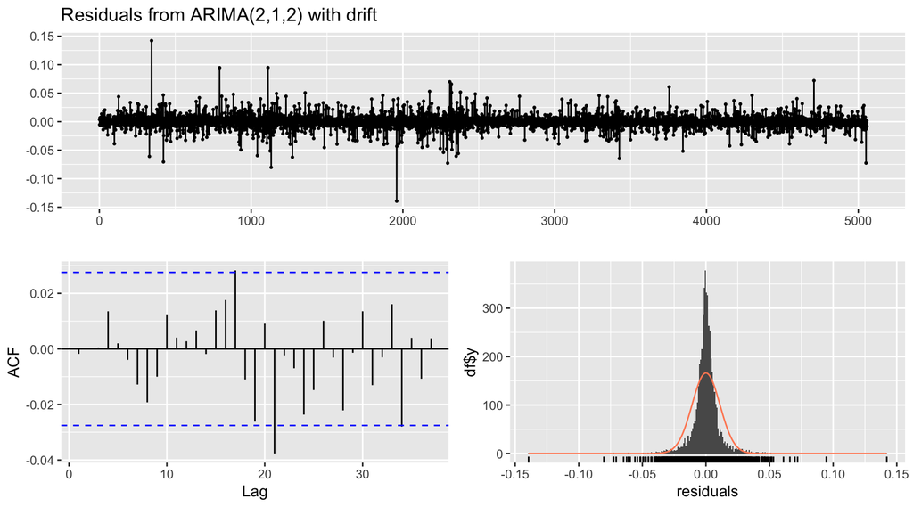

```
##
##  Ljung-Box test
##
## data:  Residuals from ARIMA(2,1,2) with drift
## Q* = 5.04, df = 6, p-value = 0.5387
##
## Model df: 4.   Total lags used: 10
```

```r
checkresiduals(res_1h[["NVDA"]]$fit, lag = 10)
```

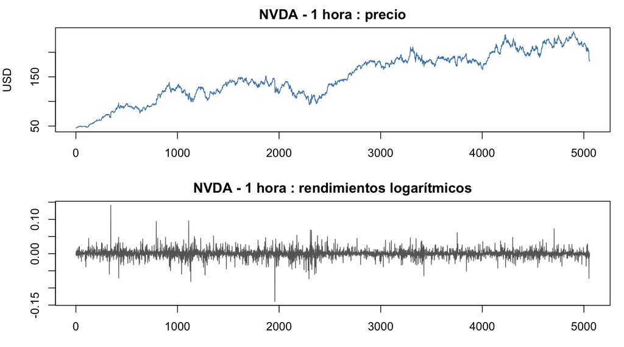

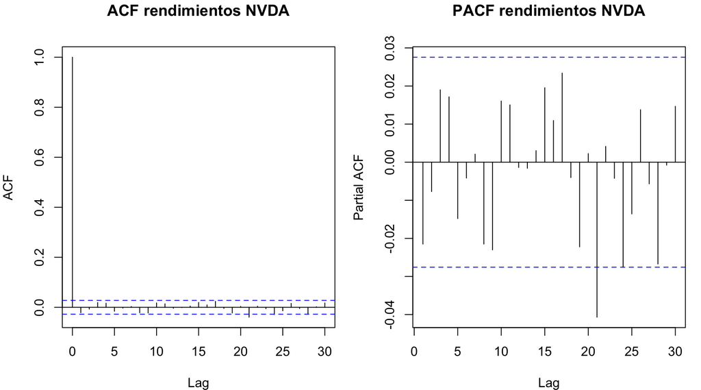

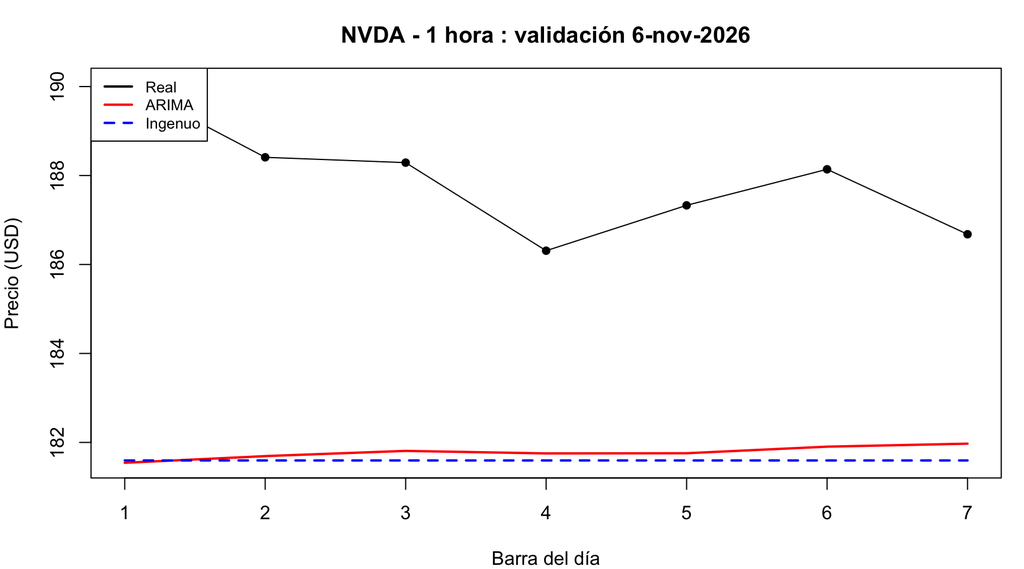

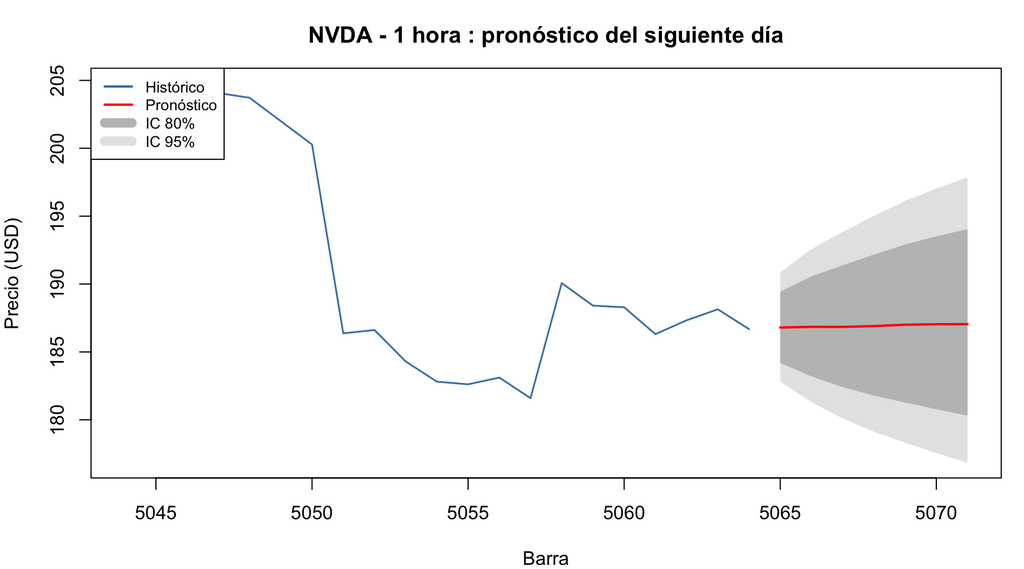

```r
graficar(res_1h, "NVDA", "1 hora")
```

```r
summary(res_5m[["NVDA"]]$fit)
```

```
## Series: lp
## ARIMA(0,1,0)
##
## sigma^2 = 0.000006638:  log likelihood = 20902.01
## AIC=-41802.01   AICc=-41802.01   BIC=-41795.58
##
## Training set error measures:
##                          ME        RMSE         MAE           MPE       MAPE
## Training set -0.00004693269 0.002576065 0.001299302 -0.0008955044 0.02412397
##                 MASE        ACF1
## Training set 1.00069 -0.02030471
```

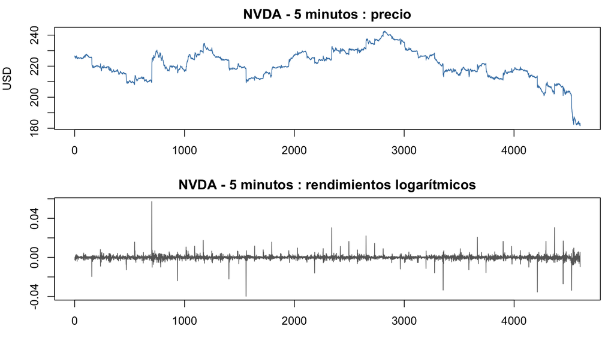

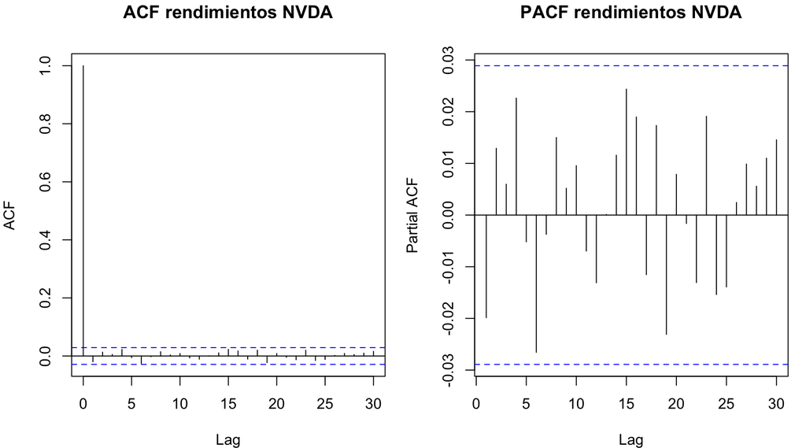

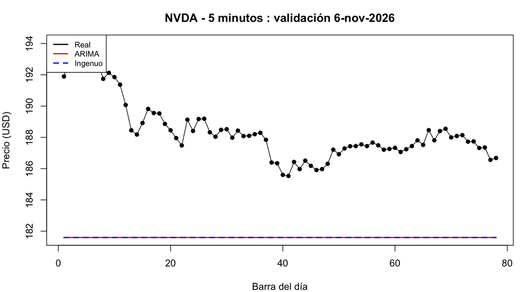

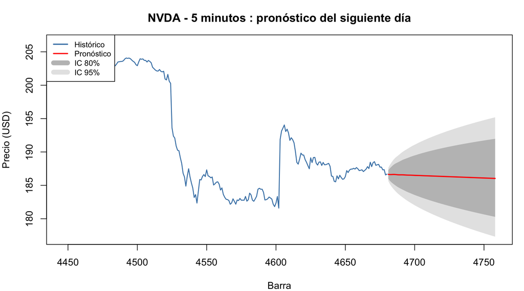

```r
graficar(res_5m, "NVDA", "5 minutos")
```

**Interpretación:** En 1 hora el modelo elegido es ARIMA(2,1,2) con deriva. Sus coeficientes AR2 (−0.887) y MA2 (0.877) son casi iguales en magnitud y de signo opuesto, por lo que prácticamente se cancelan y el modelo se comporta casi como una caminata aleatoria con deriva positiva. Ljung-Box (p = 0.54) indica que los residuales son ruido blanco, y en la validación el ARIMA le gana ligeramente al ingenuo (RMSE de 6.24 contra 6.40). En 5 minutos el modelo es directamente una caminata aleatoria, ARIMA(0,1,0).

### 4.7.2 JNJ

```r
summary(res_1h[["JNJ"]]$fit)
```

```
## Series: lp
## ARIMA(0,1,0) with drift
##
## Coefficients:
##        drift
##       0.0001
## s.e.  0.0001
##
## sigma^2 = 0.00002115:  log likelihood = 20057.68
## AIC=-40111.36   AICc=-40111.35   BIC=-40098.3
##
## Training set error measures:
##                           ME        RMSE         MAE            MPE       MAPE
## Training set 0.0000009967537 0.004598141 0.002856182 -0.00006764413 0.05465889
##                   MASE        ACF1
## Training set 0.9993702 -0.01271532
```

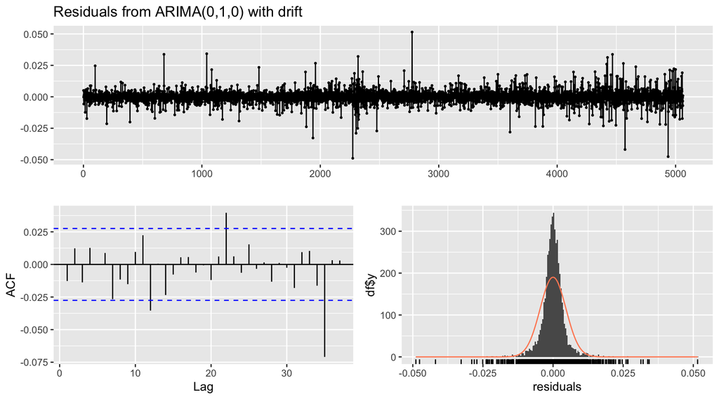

```
##
##  Ljung-Box test
##
## data:  Residuals from ARIMA(0,1,0) with drift
## Q* = 9.657, df = 10, p-value = 0.4711
##
## Model df: 0.   Total lags used: 10
```

```r
checkresiduals(res_1h[["JNJ"]]$fit, lag = 10)
```

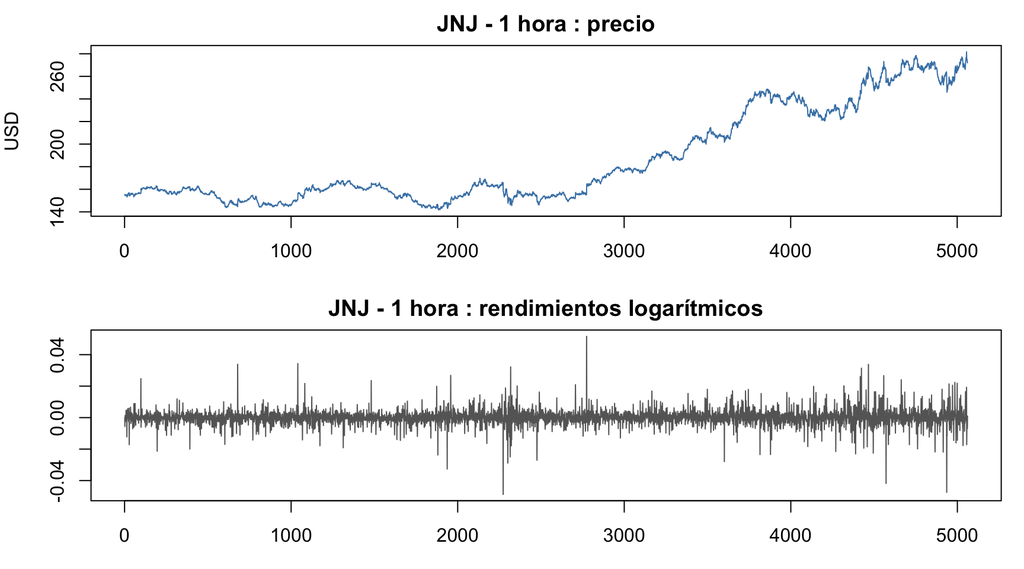

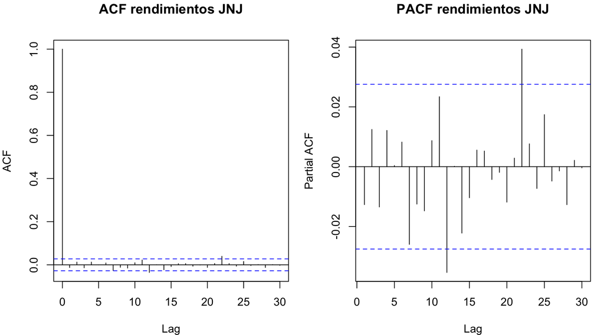

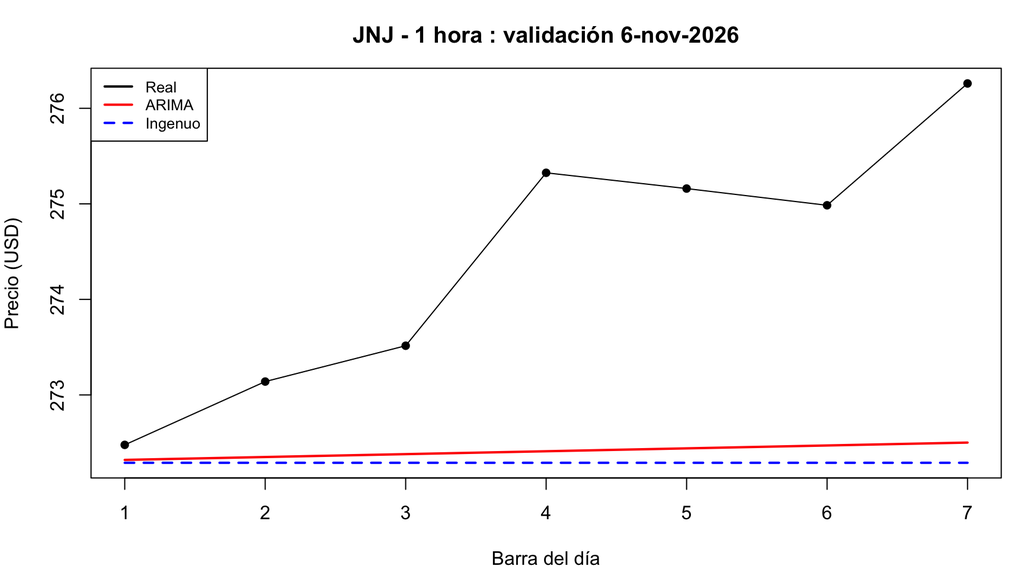

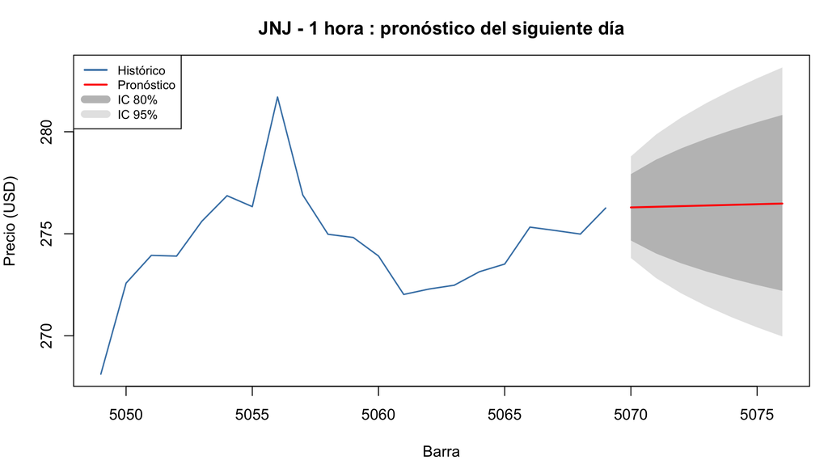

```r
graficar(res_1h, "JNJ", "1 hora")
```

```r
summary(res_5m[["JNJ"]]$fit)
```

```
## Series: lp
## ARIMA(0,1,1)
##
## Coefficients:
##           ma1
##       -0.0401
## s.e.   0.0145
##
## sigma^2 = 0.000003802:  log likelihood = 22186.54
## AIC=-44369.08   AICc=-44369.08   BIC=-44356.21
##
## Training set error measures:
##                       ME        RMSE         MAE          MPE       MAPE
## Training set 0.000010935 0.001949321 0.001011919 0.0001895346 0.01812234
##                 MASE          ACF1
## Training set 1.00024 -0.0008271134
```

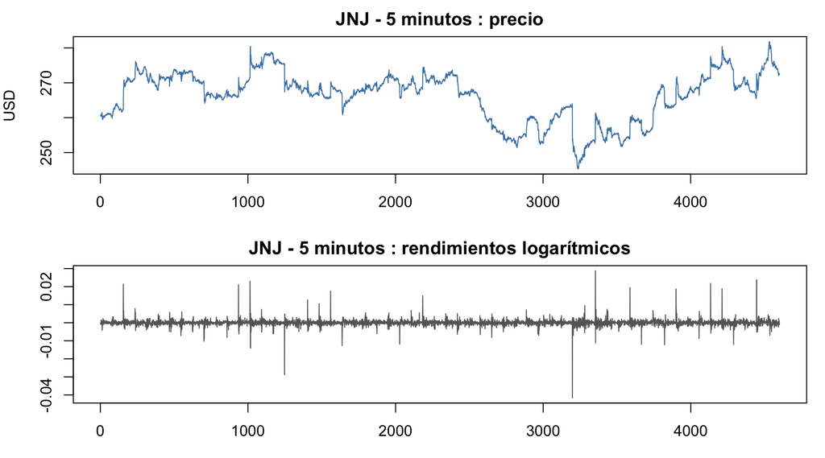

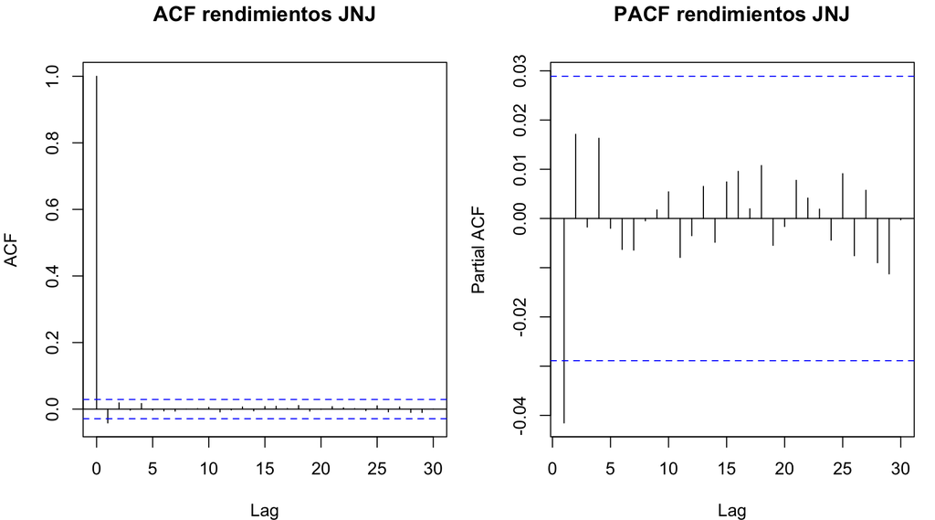

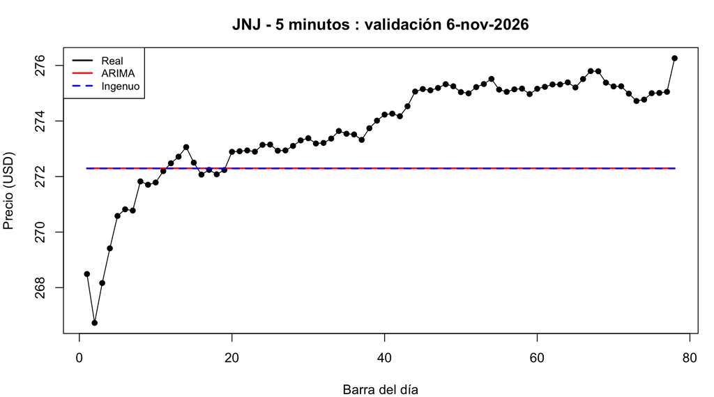

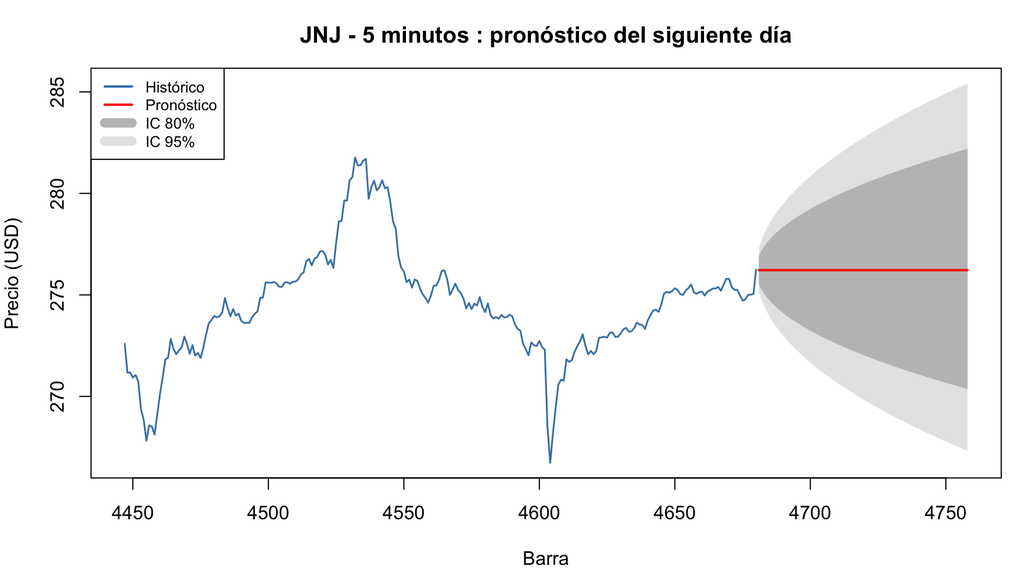

```r
graficar(res_5m, "JNJ", "5 minutos")
```

**Interpretación:** En 1 hora el modelo es una caminata aleatoria con deriva positiva (0.0001 por hora) y los residuales son ruido blanco (Ljung-Box p = 0.47). La deriva hace que le gane ligeramente al ingenuo (RMSE de 2.34 contra 2.47). En 5 minutos el modelo es ARIMA(0,1,1), con un coeficiente MA de −0.04: hay una ligera corrección del precio después de cada movimiento, y sus residuales son ruido blanco (p = 0.95).

### 4.7.3 WMT

```r
summary(res_1h[["WMT"]]$fit)
```

```
## Series: lp
## ARIMA(0,1,0) with drift
##
## Coefficients:
##        drift
##       0.0002
## s.e.  0.0001
##
## sigma^2 = 0.00003084:  log likelihood = 19088.08
## AIC=-38172.16   AICc=-38172.15   BIC=-38159.1
##
## Training set error measures:
##                           ME       RMSE         MAE          MPE       MAPE
## Training set 0.0000007738172 0.00555213 0.003176135 0.0000666158 0.07000448
##                   MASE        ACF1
## Training set 0.9979104 0.008956103
```

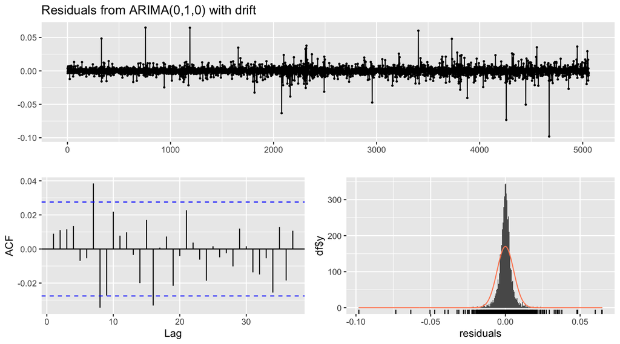

```
##
##  Ljung-Box test
##
## data:  Residuals from ARIMA(0,1,0) with drift
## Q* = 22.745, df = 10, p-value = 0.01173
##
## Model df: 0.   Total lags used: 10
```

```r
checkresiduals(res_1h[["WMT"]]$fit, lag = 10)
```

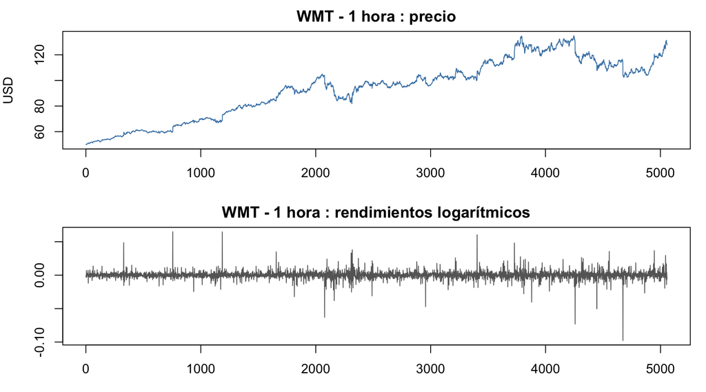

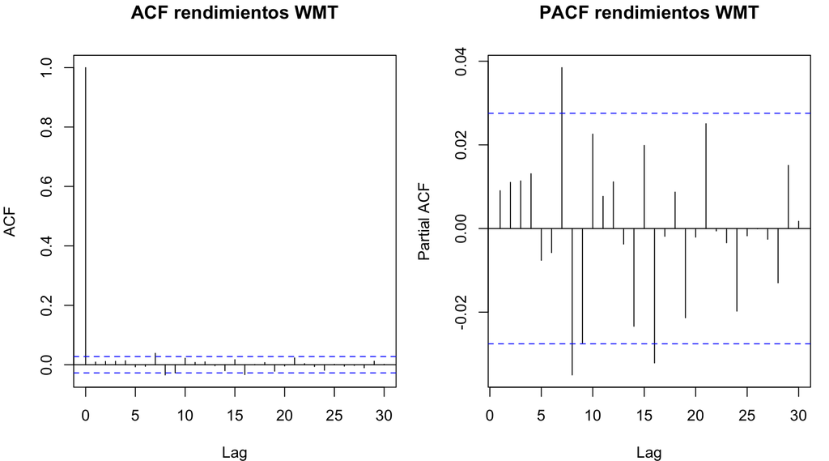

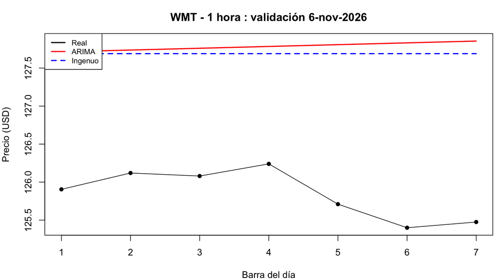

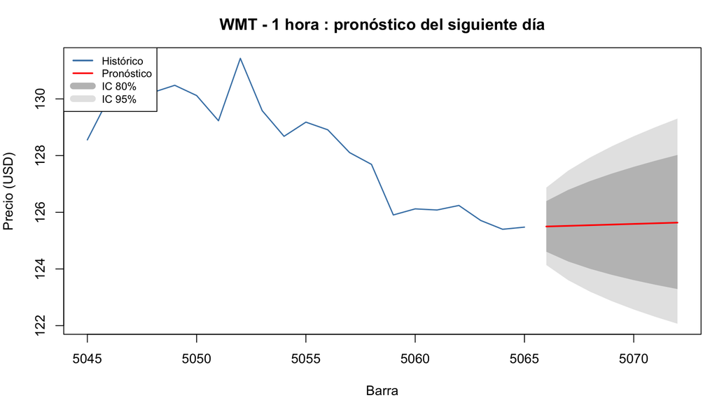

```r
graficar(res_1h, "WMT", "1 hora")
```